# Projet GLM-GAM

Axel Vossen

2025-12-08

# Part 1: GLM Analysis

## Categorical variables

Let’s start with loading the data set containing the insurance portfolio of motor third party liability (MTPL) policies from a Belgian insurer. We immediately follow up on our data preparation with converting categorical variables, wrongly saved as character type in R, into factors.

```r
load("mtpl_be.rda")
str(mtpl_be)
```

```
## 'data.frame':    163231 obs. of  18 variables:
##  $ ID      : int  1 2 3 4 5 6 7 8 9 10 ...
##  $ NCLAIMS : int  1 0 0 0 1 0 1 0 0 0 ...
##  $ AMOUNT  : num  1618 0 0 0 156 ...
##  $ AVG     : num  1618 NA NA NA 156 ...
##  $ EXP     : num  1 1 1 1 0.0466 ...
##  $ COVERAGE: chr  "TPL" "PO" "TPL" "TPL" ...
##  $ FUEL    : chr  "gasoline" "gasoline" "diesel" "gasoline" ...
##  $ USE     : chr  "private" "private" "private" "private" ...
##  $ FLEET   : chr  "N" "N" "N" "N" ...
##  $ SEX     : chr  "male" "female" "male" "male" ...
##  $ AGEPH   : int  50 64 60 77 28 26 26 58 59 34 ...
##  $ BM      : int  5 5 0 0 9 11 11 11 0 7 ...
##  $ AGEC    : int  12 3 10 15 7 12 8 14 3 6 ...
##  $ POWER   : int  77 66 70 57 70 70 55 47 98 74 ...
##  $ PC      : int  1000 1000 1000 1000 1000 1000 1000 1000 1000 1000 ...
##  $ TOWN    : chr  "BRUSSEL" "BRUSSEL" "BRUSSEL" "BRUSSEL" ...
##  $ LONG    : num  4.36 4.36 4.36 4.36 4.36 ...
##  $ LAT     : num  50.8 50.8 50.8 50.8 50.8 ...
```

```r
mtpl_be <- mtpl_be %>% mutate(COVERAGE = as.factor(COVERAGE)) %>% mutate(FUEL = as.factor(FUEL)) %>% mutate(USE = as.factor(USE)) %>% mutate(FLEET = as.factor(FLEET)) %>% mutate(SEX = as.factor(SEX))
str(mtpl_be)
```

```
## 'data.frame':    163231 obs. of  18 variables:
##  $ ID      : int  1 2 3 4 5 6 7 8 9 10 ...
##  $ NCLAIMS : int  1 0 0 0 1 0 1 0 0 0 ...
##  $ AMOUNT  : num  1618 0 0 0 156 ...
##  $ AVG     : num  1618 NA NA NA 156 ...
##  $ EXP     : num  1 1 1 1 0.0466 ...
##  $ COVERAGE: Factor w/ 3 levels "FO","PO","TPL": 3 2 3 3 3 3 1 3 1 2 ...
##  $ FUEL    : Factor w/ 2 levels "diesel","gasoline": 2 2 1 2 2 2 2 2 2 2 ...
##  $ USE     : Factor w/ 2 levels "private","work": 1 1 1 1 1 1 1 1 1 1 ...
##  $ FLEET   : Factor w/ 2 levels "N","Y": 1 1 1 1 1 1 1 1 1 1 ...
##  $ SEX     : Factor w/ 2 levels "female","male": 2 1 2 2 1 2 2 1 2 2 ...
##  $ AGEPH   : int  50 64 60 77 28 26 26 58 59 34 ...
##  $ BM      : int  5 5 0 0 9 11 11 11 0 7 ...
##  $ AGEC    : int  12 3 10 15 7 12 8 14 3 6 ...
##  $ POWER   : int  77 66 70 57 70 70 55 47 98 74 ...
##  $ PC      : int  1000 1000 1000 1000 1000 1000 1000 1000 1000 1000 ...
##  $ TOWN    : chr  "BRUSSEL" "BRUSSEL" "BRUSSEL" "BRUSSEL" ...
##  $ LONG    : num  4.36 4.36 4.36 4.36 4.36 ...
##  $ LAT     : num  50.8 50.8 50.8 50.8 50.8 ...
```

Now that we have proper factors for our categorical variables, we will assess whether the reference level, is the most appropriate one. Let’s recall that the reference level is usually fixed as the first term when treating such data set, while we aim to fix the reference level to the factor with the most occurrence. To help us, we use the **fct_count** function from package *forecats* to evaluate the number of rows for each level of the factor variables. To fasten our computation, we have decided to use right after the function **fct_infreq** from the *forecats* package as well, which will directly reassign the reference level to the most frequent factor.

### Coverage

In this variable, we deal with the type of coverage provided by the insurance policy: only third-party liability (TPL), partial omnium (PO) and full omnium (FO). Note that Partial omnium is equal to *TPL* + limited material damage, while full omnium corresponds to *TPL* + comprehensive material damage.

```r
levels(mtpl_be$COVERAGE)
```

```
## [1] "FO"  "PO"  "TPL"
```

We observe that the reference level is initially set to *FO*, being the first factor of the Coverage variable. But with the output from *fct_count*, we understand that *TPL* is actually the reference level with the most observations.

```r
mtpl_be$COVERAGE %>% fct_count(sort=TRUE,prop = TRUE)
```

```
## # A tibble: 3 × 3
##   f         n     p
##   <fct> <int> <dbl>
## 1 TPL   95136 0.583
## 2 PO    45988 0.282
## 3 FO    22107 0.135
```

Therefore, we use the function *fct_infreq* to relevel properly with respect to the highest observed factor. Another alternative would be to use the function **relevel**.

```r
mtpl_be$COVERAGE = mtpl_be$COVERAGE %>% fct_infreq()
```

### Fuel

Regarding the type of fuel of the vehicles, *diesel* appears to be the reference level.

```r
levels(mtpl_be$FUEL)
```

```
## [1] "diesel"   "gasoline"
```

But from the following output *gasoline* is the most common of the two.

```r
mtpl_be$FUEL %>% fct_count(sort=TRUE,prop = TRUE)
```

```
## # A tibble: 2 × 3
##   f             n     p
##   <fct>     <int> <dbl>
## 1 gasoline 112833 0.691
## 2 diesel    50398 0.309
```

```r
mtpl_be$Fuel = mtpl_be$FUEL %>% fct_infreq()
```

### Use

Let’s now tackle the type of use of the vehicle between *private* and *work*. The reference level is *private*.

```r
levels(mtpl_be$USE)
```

```
## [1] "private" "work"
```

Meanwhile, it appears that the reference level is rightly chosen as the *private* use is the most common with approximately 95.17% occurrence.

```r
mtpl_be$USE %>% fct_count(sort=TRUE,prop = TRUE)
```

```
## # A tibble: 2 × 3
##   f            n      p
##   <fct>    <int>  <dbl>
## 1 private 155352 0.952
## 2 work      7879 0.0483
```

### Fleet

We will now deal with this categorical variable designating if the the vehicle is part of a fleet. The reference level is defined as *N* standing for No.

```r
levels(mtpl_be$FLEET)
```

```
## [1] "N" "Y"
```

Again, we don’t need to further process the data as most vehicles are not part of a fleet.

```r
mtpl_be$FLEET %>% fct_count(sort=TRUE,prop = TRUE)
```

```
## # A tibble: 2 × 3
##   f          n      p
##   <fct>  <int>  <dbl>
## 1 N     158060 0.968
## 2 Y       5171 0.0317
```

### Sex

The final categorical variable we will deal with is the gender of the policyholder between *male* and *female*, with the latter defined as the reference level.

```r
levels(mtpl_be$SEX)
```

```
## [1] "female" "male"
```

With respect to the output from the *fct_count* function, the male gender is the most represented in the data set.

```r
mtpl_be$SEX %>% fct_count(sort=TRUE,prop = TRUE)
```

```
## # A tibble: 2 × 3
##   f           n     p
##   <fct>   <int> <dbl>
## 1 male   120056 0.735
## 2 female  43175 0.265
```

Which we thus reassign with the *fct_infreq* function.

```r
mtpl_be$SEX = mtpl_be$SEX %>% fct_infreq()
```

## Continuous variables

Moreover, for the sake of simplifying our analysis, we process the following continuous variables: *ageph*, *agec*, *power* and *bm*. To this end, the idea is to bin continuous variables. To do so, I will first rely on the *discretize* function from package **recipe**. I will iterativelly try different cuts value, until it shows warning stating that the binning function refuses to discretize due to lack of enough distinct values without producing degenerate bins. Then we apply the *mutate* and *cut* functions on the continuous variable to classify them in factor-type categories.

### Ageph

First, we deal with the age of the policyholders in years, from 18 to 95 years old.

```r
min(mtpl_be$AGEPH);max(mtpl_be$AGEPH)
```

```
## [1] 18
```

```
## [1] 95
```

We thus apply the *discretize* function and find an appropriate cuts amount of 6.

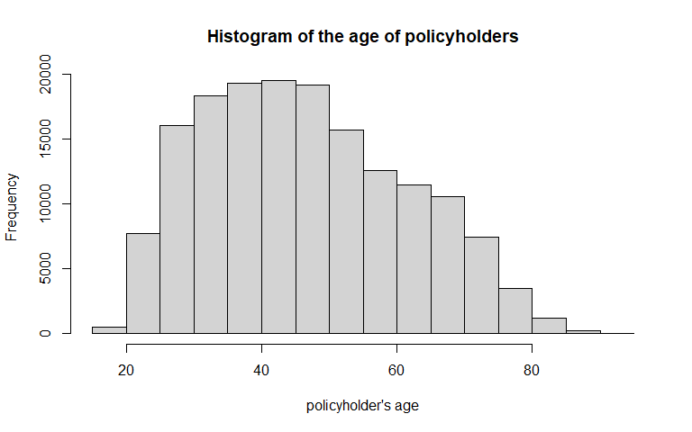

```r
hist(mtpl_be$AGEPH, main = "Histogram of the age of policyholders", xlab= "policyholder's age")
```

```r
mtpl_be$AGEPH %>% discretize(mtpl_be$AGEPH, cuts=5)
```

```
## Bins: 163232 (includes missing category)
## Breaks: -Inf, 33, 41, 50, 61, Inf
```

```r
mtpl_be$AGEPH %>% discretize(mtpl_be$AGEPH, cuts=6)
```

```
## Bins: 163232 (includes missing category)
```

```r
mtpl_be$AGEPH %>% discretize(mtpl_be$AGEPH, cuts=7)
```

```
## Too few unique data points. No binning was used.
```

We thus obtain the following age

```r
mtpl_be <- mtpl_be %>% mutate(AGEPH_fac = cut(AGEPH , breaks=6 ))
levels(mtpl_be$AGEPH_fac)
```

```
## [1] "(17.9,30.8]" "(30.8,43.7]" "(43.7,56.5]" "(56.5,69.3]" "(69.3,82.2]"
## [6] "(82.2,95.1]"
```

The final step is to assign the proper reference level, as we did with categorical values. We identify the bin of ages (30.8,43.7] as being the most observed (30.24%), which is then set with the *fct_infreq* function.

```r
mtpl_be$AGEPH_fac %>% fct_count(sort=TRUE,prop = TRUE)
```

```
## # A tibble: 6 × 3
##   f               n       p
##   <fct>       <int>   <dbl>
## 1 (30.8,43.7] 49357 0.302
## 2 (43.7,56.5] 44812 0.275
## 3 (56.5,69.3] 30498 0.187
## 4 (17.9,30.8] 24295 0.149
## 5 (69.3,82.2] 13363 0.0819
## 6 (82.2,95.1]   906 0.00555
```

```r
mtpl_be$AGEPH_fac = mtpl_be$AGEPH_fac %>% fct_infreq()
```

### Agec

Secondly, we deal with the age of the vehicles in years, between 0 and 48 years old.

```
## [1] 0
```

```
## [1] 48
```

We thus apply the *discretize* function and find an appropriate cuts amount of 3.

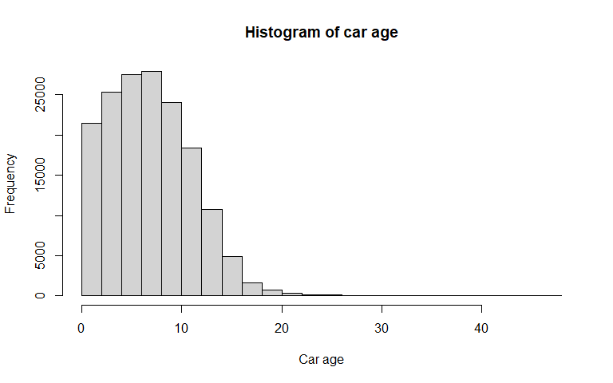

```r
hist(mtpl_be$AGEC, main="Histogram of car age", xlab="Car age")
```

```r
mtpl_be$AGEC %>% discretize(mtpl_be$AGEC, cuts=2)
```

```
## Bins: 163232 (includes missing category)
## Breaks: -Inf, 7, Inf
```

```r
mtpl_be$AGEC %>% discretize(mtpl_be$AGEC, cuts=3)
```

```
## Bins: 163232 (includes missing category)
## Breaks: -Inf, 5, 9, Inf
```

```r
mtpl_be$AGEC %>% discretize(mtpl_be$AGEC, cuts=4)
```

```
## Too few unique data points. No binning was used.
```

We thus obtain the following age bins for the vehicles.

```r
mtpl_be <- mtpl_be %>% mutate(AGEC_fac = cut(AGEC , breaks=c(-0.5,5,9,max(mtpl_be$AGEC))))
levels(mtpl_be$AGEC_fac)
```

```
## [1] "(-0.5,5]" "(5,9]"    "(9,48]"
```

The reference level remains unchanged as vehicles between 0 and 5 years old represent 36.27% of all vehicles registered.

```r
mtpl_be$AGEC_fac %>% fct_count(sort=TRUE,prop = TRUE)
```

```
## # A tibble: 3 × 3
##   f            n     p
##   <fct>    <int> <dbl>
## 1 (-0.5,5] 59205 0.363
## 2 (5,9]    55419 0.340
## 3 (9,48]   48607 0.298
```

### Power

Let’s investigate the horsepower of vehicles in kilowatt in a range of 10 to 243. Naturally, the more horsepower a vehicle has, the more kilowatts it represents

```
## [1] 10
```

```
## [1] 243
```

We find the optimal amount of cuts being equal to 5.

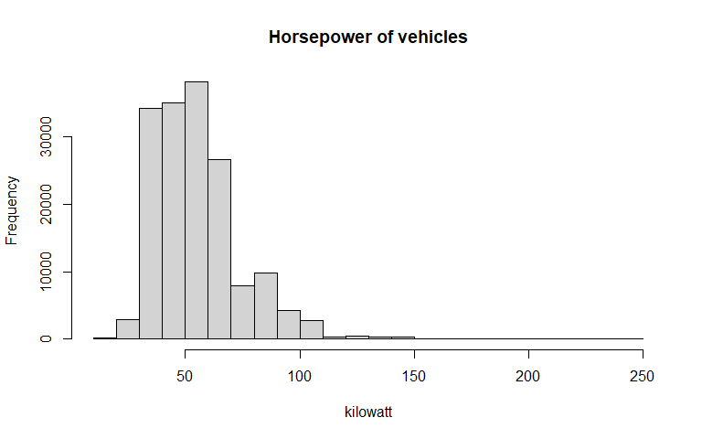

```r
hist(mtpl_be$POWER, main = "Horsepower of vehicles", xlab="kilowatt")
```

```r
mtpl_be$POWER %>% discretize(mtpl_be$POWER, cuts=3)
```

```
## Bins: 163232 (includes missing category)
## Breaks: -Inf, 44, 60, Inf
```

```r
mtpl_be$POWER %>% discretize(mtpl_be$POWER, cuts=4)
```

```
## Bins: 163232 (includes missing category)
## Breaks: -Inf, 43, 53, 66, Inf
```

```r
mtpl_be$POWER %>% discretize(mtpl_be$POWER, cuts=5)
```

```
## Bins: 163232 (includes missing category)
## Breaks: -Inf, 40, 48, 55, 66, Inf
```

```r
mtpl_be$POWER %>% discretize(mtpl_be$POWER, cuts=6)
```

```
## Bins: 163232 (includes missing category)
```

These are the different factor ranges.

```r
mtpl_be <- mtpl_be %>% mutate(POWER_fac = cut(POWER , breaks=c(-0.5, 40, 48, 55, 66, max(mtpl_be$POWER))))
levels(mtpl_be$POWER_fac)
```

```
## [1] "(-0.5,40]" "(40,48]"   "(48,55]"   "(55,66]"   "(66,243]"
```

The reference level remains unchanged as the highest percentage of observed horsepower is in the range 0 to 40.

```r
mtpl_be$POWER_fac %>% fct_count(sort=TRUE,prop = TRUE)
```

```
## # A tibble: 5 × 3
##   f             n     p
##   <fct>     <int> <dbl>
## 1 (-0.5,40] 37271 0.228
## 2 (48,55]   35584 0.218
## 3 (66,243]  31741 0.194
## 4 (40,48]   29488 0.181
## 5 (55,66]   29147 0.179
```

### Bm

The final variable we will be processing is the one relative to the level in the former compulsory Belgian bonus-malus scale. It goes from level 0 to 22, where the higher level indicates the worse claim history.

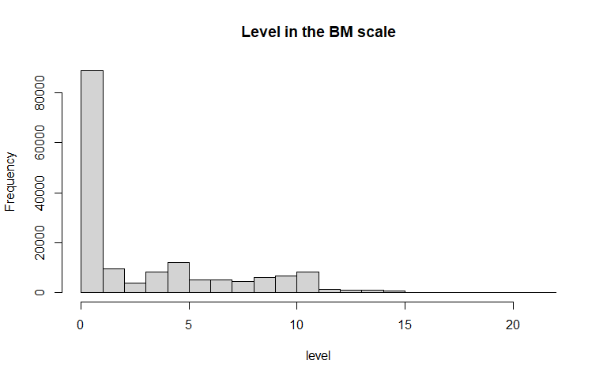

```r
hist(mtpl_be$BM, main = "Level in the BM scale", xlab="level")
```

Since the discretize function does not provide any suggestion of bins, we made assumptions based on the histogram, and chose the following four categories

```r
mtpl_be <- mtpl_be %>% mutate(BM_fac = cut(BM, breaks=c(-0.5,0, 5,11, max(mtpl_be$BM))))
levels(mtpl_be$BM_fac)
```

```
## [1] "(-0.5,0]" "(0,5]"    "(5,11]"   "(11,22]"
```

Although the first factor only accounts for level 0, it is clearly the most observed value and deserved to be on its own. To support my assumption, we see that it may remain as the reference level since it gathers approximately 37.77% of the policyholders.

```r
mtpl_be$BM_fac %>% fct_count(sort=TRUE,prop = TRUE)
```

```
## # A tibble: 4 × 3
##   f            n      p
##   <fct>    <int>  <dbl>
## 1 (-0.5,0] 61650 0.378
## 2 (0,5]    60742 0.372
## 3 (5,11]   36247 0.222
## 4 (11,22]   4592 0.0281
```

## Exploratory data analysis

We completed the first key part of working with data which is data processing. In this section, we will represent in a more visual way the different values we are dealing with to further fit our GLM. Indeed, in this section, we will investigate how each information from policyholders have an influence on the claim frequency.

### Coverage

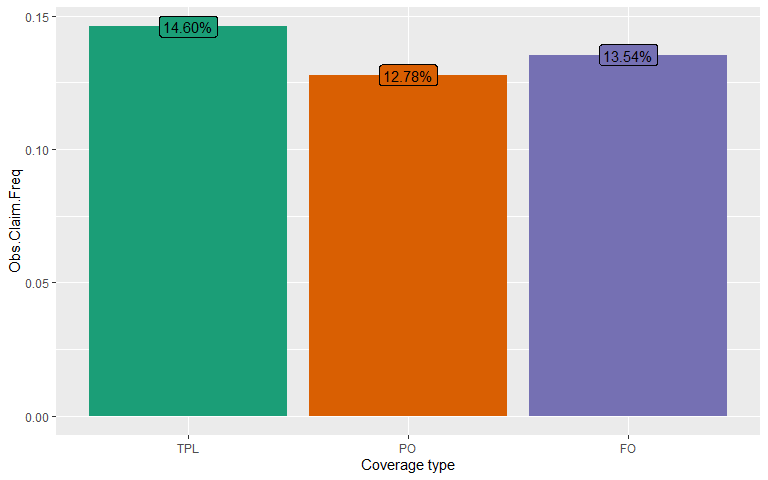

```r
# Summarise coverage
cov_summary <- mtpl_be %>%
  group_by(COVERAGE) %>%
  summarise(
    totalExposure = sum(EXP),
    Number.Claims = sum(NCLAIMS),
    Obs.Claim.Freq = sum(NCLAIMS) / sum(EXP),
    .groups = "drop"
  )

ggplot(
  cov_summary,
  aes(
    x = COVERAGE, y = Obs.Claim.Freq,
    fill = COVERAGE,
    label = percent(Obs.Claim.Freq, accuracy=0.01)
  )
) +
  geom_bar(stat = "identity") +
  geom_label() +
  guides(fill = "none") +
  scale_x_discrete(name = "Coverage type" ) +
  scale_fill_brewer(palette = "Dark2")
```

```r
  scale_y_continuous("Observed claim Frequency", labels = label_percent())
```

```
## <ScaleContinuousPosition>
##  Range:
##  Limits:    0 --    1
```

### Fuel

Here we observe that Fuel represents an important factor in claim frequency with *diesel* scoring more than 2.5% more than *gasoline*

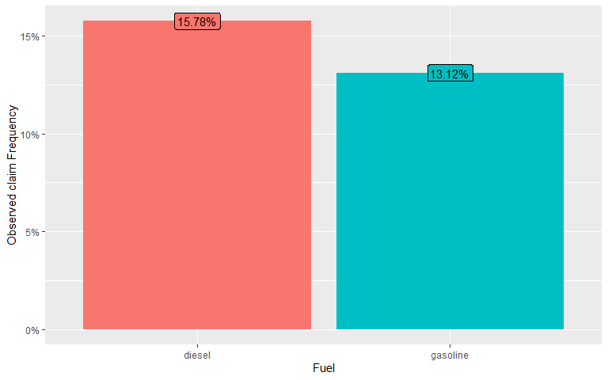

```r
gas_summary <- mtpl_be %>%
  group_by(FUEL) %>%
  summarise(
    totalExposure = sum(EXP),
    Number.Observations = length(EXP),
    Number.Claims = sum(NCLAIMS),
    Obs.Claim.Freq = sum(NCLAIMS) / sum(EXP)
  )

ggplot(
  gas_summary,
  aes(
    x = FUEL, y = Obs.Claim.Freq,
    fill = FUEL,
    label = percent(Obs.Claim.Freq, accuracy=0.01)
  )
) +
  geom_bar(stat = "identity") +
  geom_label() +
  guides(fill = "none") +
  scale_x_discrete(name = "Fuel") +
  scale_y_continuous("Observed claim Frequency", labels = label_percent())
```

### Sex

In this case we observe the difference in claims frequency between men and women. Based on the observed data in our data set, women tend to cause more claims than man with an increase of 1.23%.

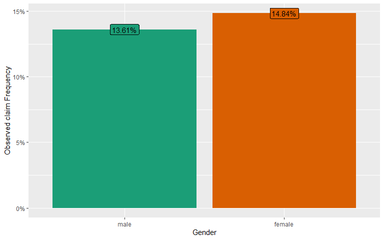

```r
sex_summary <- mtpl_be %>%
  group_by(SEX) %>%
  summarise(
    totalExposure = sum(EXP),
    Number.Observations = length(EXP),
    Number.Claims = sum(NCLAIMS),
    Obs.Claim.Freq = sum(NCLAIMS) / sum(EXP)
  )

ggplot(
  sex_summary,
  aes(
    x = SEX, y = Obs.Claim.Freq,
    fill = SEX,
    label = percent(Obs.Claim.Freq, accuracy=0.01)
  )
) +
  geom_bar(stat = "identity") +
  geom_label() +
  guides(fill = "none") +
  scale_x_discrete(name = "Gender") +
  scale_y_continuous("Observed claim Frequency", labels = label_percent())+
  scale_fill_brewer(palette="Dark2")
```

### Use

When investigating the use of the car, we observe only a slight difference in frequency, which gives us the insight that this information is not the most important one when modelling claim frequencies.

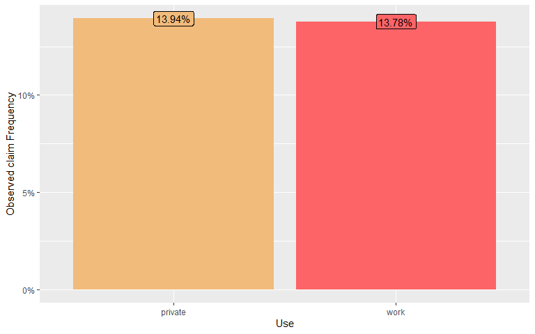

```r
use_summary <- mtpl_be %>%
  group_by(USE) %>%
  summarise(
    totalExposure = sum(EXP),
    Number.Observations = length(EXP),
    Number.Claims = sum(NCLAIMS),
    Obs.Claim.Freq = sum(NCLAIMS) / sum(EXP)
  )

ggplot(
  use_summary,
  aes(
    x = USE, y = Obs.Claim.Freq,
    fill = USE,
    label = percent(Obs.Claim.Freq, accuracy=0.01)
  )
) +
  geom_bar(stat = "identity") +
  geom_label() +
  guides(fill = "none") +
  scale_x_discrete(name = "Use") +
  scale_y_continuous("Observed claim Frequency", labels = label_percent())+
  scale_fill_manual(values=wes_palette(name="GrandBudapest1"))
```

### Fleet

On the other hand, not being part of a fleet tends to cause almost 3% more claims than being in one.

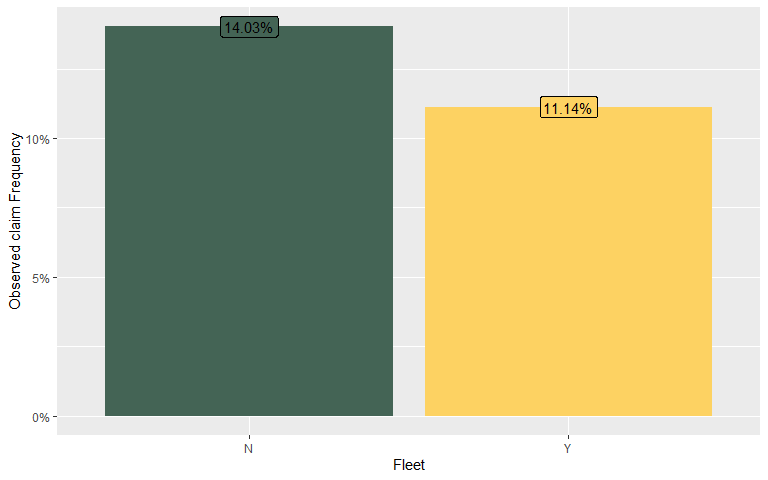

```r
fleet_summary <- mtpl_be %>%
  group_by(FLEET) %>%
  summarise(
    totalExposure = sum(EXP),
    Number.Observations = length(EXP),
    Number.Claims = sum(NCLAIMS),
    Obs.Claim.Freq = sum(NCLAIMS) / sum(EXP)
  )

ggplot(
  fleet_summary,
  aes(
    x = FLEET, y = Obs.Claim.Freq,
    fill =FLEET,
    label = percent(Obs.Claim.Freq, accuracy=0.01)
  )
) +
  geom_bar(stat = "identity") +
  geom_label() +
  guides(fill = "none") +
  scale_x_discrete(name = "Fleet") +
  scale_y_continuous("Observed claim Frequency", labels = label_percent())+
  scale_fill_manual(values=wes_palette(name="Chevalier1"))
```

### ageph

We know from a fact that the age of the policyholder is an important information regarding claim frequency. This argument is supported with the following graph showing young drivers between 18 and 31 having much higher frequency than any other subgroups, peaking at 21.36%. We then observe claim frequency decreasing with age until observing an upward trend for elderlies above 82. This trend is actually quite representative of what might be observed in other data sets and research studies.

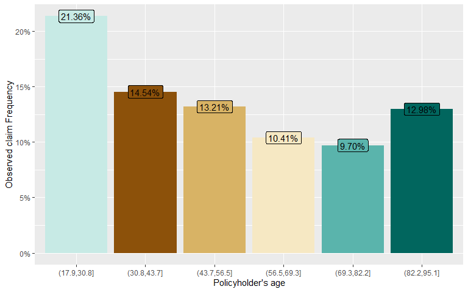

```r
ageph_summary <- mtpl_be %>%
  group_by(AGEPH_fac) %>%
  summarise(
    totalExposure = sum(EXP),
    Number.Observations = length(EXP),
    Number.Claims = sum(NCLAIMS),
    Obs.Claim.Freq = sum(NCLAIMS) / sum(EXP)
  )

ggplot(
  ageph_summary,
  aes(
    x = reorder(AGEPH_fac,c(2,3,4,1,5,6), decreasing=FALSE), y = Obs.Claim.Freq,
    fill =AGEPH_fac,
    label = percent(Obs.Claim.Freq, accuracy=0.01)
  )
) +
  geom_bar(stat = "identity") +
  geom_label() +
  guides(fill = "none") +
  scale_x_discrete(name = "Policyholder's age") +
  scale_y_continuous("Observed claim Frequency", labels = label_percent())+
  scale_fill_brewer(palette = "BrBG")
```

### Age C

We tend to see a slight increase of the number of claims when the car gets older. Indeed, the interval (9,48] scores 1% more than cars between 0 and 5 years old and 0.5% for cars aged between 6 and 9.

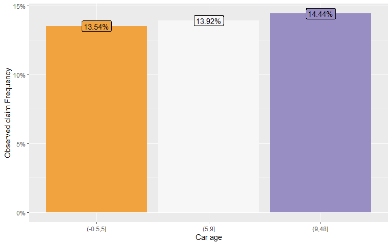

```r
agec_summary <- mtpl_be %>%
  group_by(AGEC_fac) %>%
  summarise(
    totalExposure = sum(EXP),
    Number.Observations = length(EXP),
    Number.Claims = sum(NCLAIMS),
    Obs.Claim.Freq = sum(NCLAIMS) / sum(EXP)
  )

ggplot(
  agec_summary,
  aes(
    x = AGEC_fac, y = Obs.Claim.Freq,
    fill =AGEC_fac,
    label = percent(Obs.Claim.Freq, accuracy=0.01)
  )
) +
  geom_bar(stat = "identity") +
  geom_label() +
  guides(fill = "none") +
  scale_x_discrete(name = "Car age") +
  scale_y_continuous("Observed claim Frequency", labels = label_percent())+
  scale_fill_brewer(palette = "PuOr")
```

### Power

Although we might expect the power of the vehicle to have a huge impact on the number of claims, we observe slight differences between categories. But lowest power in kilowatts still has the lowest frequency while the highest category rises by apporximately 1.6% from the reference level.

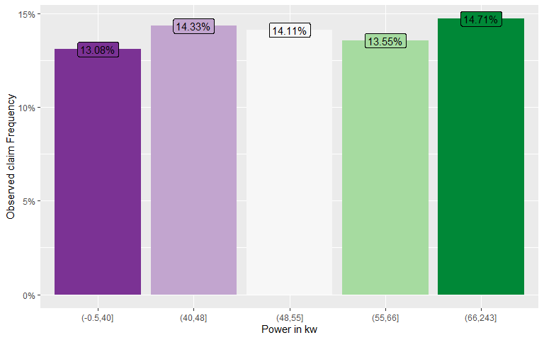

```r
pow_summary <- mtpl_be %>%
  group_by(POWER_fac) %>%
  summarise(
    totalExposure = sum(EXP),
    Number.Observations = length(EXP),
    Number.Claims = sum(NCLAIMS),
    Obs.Claim.Freq = sum(NCLAIMS) / sum(EXP)
  )


ggplot(
  pow_summary,
  aes(
    x = POWER_fac, y = Obs.Claim.Freq,
    fill =POWER_fac,
    label = percent(Obs.Claim.Freq, accuracy=0.01)
  )
) +
  geom_bar(stat = "identity") +
  geom_label() +
  guides(fill = "none") +
  scale_x_discrete(name = "Power in kw") +
  scale_y_continuous("Observed claim Frequency", labels = label_percent())+
  scale_fill_brewer(palette = "PRGn")
```

Although the plot above shows that the frequency of claims is higher for high power, for the sake of visualization only, we have subdivided the categories even more to better show the linear relationship with power. We won’t use this classification since the extreme categories are too small sampled compared to others which might bias our statistical analysis. Therefore, we will stick with our former intervals regarding POWER for later use.

```r
mtpl_be2 <- mtpl_be %>% mutate(POWER_fac = cut(POWER , breaks=c(-0.5, 20, 60, 70, 110, max(mtpl_be$POWER))))
mtpl_be2$POWER_fac %>% fct_count(sort=TRUE,prop = TRUE)
```

```
## # A tibble: 5 × 3
##   f              n       p
##   <fct>      <int>   <dbl>
## 1 (20,60]   110122 0.675
## 2 (60,70]    26596 0.163
## 3 (70,110]   24679 0.151
## 4 (110,243]   1637 0.0100
## 5 (-0.5,20]    197 0.00121
```

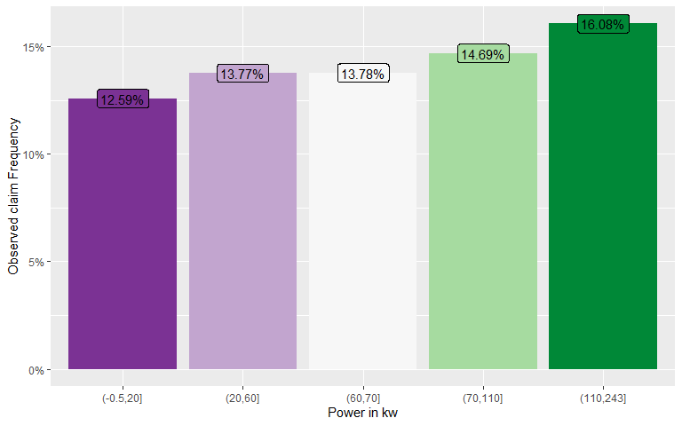

```r
pow_summary2 <- mtpl_be2 %>%
  group_by(POWER_fac) %>%
  summarise(
    totalExposure = sum(EXP),
    Number.Observations = length(EXP),
    Number.Claims = sum(NCLAIMS),
    Obs.Claim.Freq = sum(NCLAIMS) / sum(EXP)
  )


ggplot(
  pow_summary2,
  aes(
    x = POWER_fac, y = Obs.Claim.Freq,
    fill =POWER_fac,
    label = percent(Obs.Claim.Freq, accuracy=0.01)
  )
) +
  geom_bar(stat = "identity") +
  geom_label() +
  guides(fill = "none") +
  scale_x_discrete(name = "Power in kw") +
  scale_y_continuous("Observed claim Frequency", labels = label_percent())+
  scale_fill_brewer(palette = "PRGn")
```

Here we thus observe clearly that claims are more frequent as the car’s horsepower increases.

### BM

Lastly, when investigating the relation between the Bonus-malus scale and the frequency of claims, we observe a clear increase when going up the ladder. The results can be intuitively assumed since a policyholder will go up the ladder when he or she reports a claim where he or she is at fault. Naturally, the more the persons reports claims, the more that person will be up on the ladder and higher claim frequency might be observed in higher intervals. Although the reference level is level 0, the claim frequency more than doubles compared to levels between 12 and 22. One might think that these observations are biased since the category 12 to 22 gathers half the levels in the BM scale, but it actually accounts for 2.81% of the policyholders. The results are then really self-explanatory.

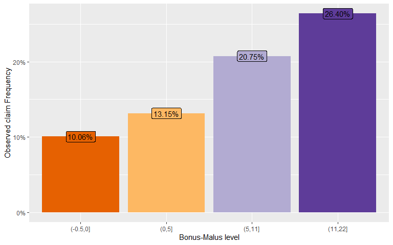

```r
bm_summary <- mtpl_be %>%
  group_by(BM_fac) %>%
  summarise(
    totalExposure = sum(EXP),
    Number.Observations = length(EXP),
    Number.Claims = sum(NCLAIMS),
    Obs.Claim.Freq = sum(NCLAIMS) / sum(EXP)
  )

ggplot(
  bm_summary,
  aes(
    x = BM_fac, y = Obs.Claim.Freq,
    fill =BM_fac,
    label = percent(Obs.Claim.Freq, accuracy=0.01)
  )
) +
  geom_bar(stat = "identity") +
  geom_label() +
  guides(fill = "none") +
  scale_x_discrete(name = "Bonus-Malus level") +
  scale_y_continuous("Observed claim Frequency", labels = label_percent())+
  scale_fill_brewer(palette = "PuOr")
```

## Frequency Model (Poisson)

After getting more insights on the arguments relative to our insurance portfolio, we will start to fit GLM’s models and see which one is the most optimal, based on the variables explored before. Here we investigate models based on the frequency, defined by the argument *NCLAIMS* in our data set. We will start our development with the hypothesis that the frequency follows a Poisson distribution, the same way as it is usually assumed.

To help us determine which model is the most optimal, we separate the data set into a training and a test set with the help of the function *createDataPartition* from the **caret** package. The p argument defines the percentage of data in the training set. The idea will be to fit the model based on the values of the training set and compare the fitted, as well as the predicted values with respect to the test set to evaluate if models capture appropriately the underlying features of the variables.

```r
set.seed(21)  # For reproducibility
in_training = createDataPartition(mtpl_be$NCLAIMS, times = 1, p = 0.8, list = FALSE)
training_set = mtpl_be[in_training, ]
testing_set = mtpl_be[-in_training, ]
```

Now, we run the *glm* function on our training set with respect to the number of claims (*NCLAIMS*). As offset, we use the log_link function of the exposure. Our initial model *m0* includes only the intercept, knowingly the log(exposure).

```r
m0 <- glm(NCLAIMS ~ offset(log(EXP)), data = training_set, family = poisson())
summary(m0)
```

```
##
## Call:
## glm(formula = NCLAIMS ~ offset(log(EXP)), family = poisson(),
##     data = training_set)
##
## Coefficients:
##              Estimate Std. Error z value Pr(>|z|)
## (Intercept) -1.967969   0.007851  -250.7   <2e-16 ***
## ---
## Signif. codes:  0 '***' 0.001 '**' 0.01 '*' 0.05 '.' 0.1 ' ' 1
##
## (Dispersion parameter for poisson family taken to be 1)
##
##     Null deviance: 71970  on 130584  degrees of freedom
## Residual deviance: 71970  on 130584  degrees of freedom
## AIC: 102284
##
## Number of Fisher Scoring iterations: 6
```

We can understand a glm model with only the exponential of the intercept $\exp\beta_0$ as the average claim frequency such that: $\exp\beta_0$ = $\displaystyle\frac{\sum_i NCLAIMS_i}{\sum_i Exposure_i}$. This may be verified with the following computation:

```r
a <- list(exp(m0$coef[1]), # m0$coef[1] is the Intercept
     with(training_set, sum(NCLAIMS) / sum(EXP)))
log(a[[1]])
```

```
## (Intercept)
##   -1.967969
```

To enhance our initial model, we will consider the additional discrete variables and binned continuous variables we explored in the previous sections, but we include the variables without interaction. Since GLMs are not well equipped to manage continuous random variables, we will exclude from the model the longitude and latitude spatial variables. But we will still consider the other discretized continuous variables. We thus define the full model in *m1*.

```r
m1 <- glm(NCLAIMS ~ offset(log(EXP))+ COVERAGE + FUEL + SEX + USE + FLEET+
            AGEPH_fac + AGEC_fac + POWER_fac + BM_fac, data =
            training_set, family = poisson(link=log))
summary(m1)
```

```
##
## Call:
## glm(formula = NCLAIMS ~ offset(log(EXP)) + COVERAGE + FUEL +
##     SEX + USE + FLEET + AGEPH_fac + AGEC_fac + POWER_fac + BM_fac,
##     family = poisson(link = log), data = training_set)
##
## Coefficients:
##                      Estimate Std. Error z value Pr(>|z|)
## (Intercept)          -2.20325    0.03371 -65.349  < 2e-16 ***
## COVERAGEPO           -0.06361    0.01927  -3.300 0.000966 ***
## COVERAGEFO           -0.02544    0.02694  -0.944 0.345029
## FUELgasoline         -0.17556    0.01754 -10.012  < 2e-16 ***
## SEXfemale             0.04212    0.01818   2.317 0.020502 *
## USEwork              -0.06347    0.03748  -1.693 0.090407 .
## FLEETY               -0.14939    0.04890  -3.055 0.002250 **
## AGEPH_fac(43.7,56.5] -0.02040    0.02100  -0.972 0.331276
## AGEPH_fac(56.5,69.3] -0.22213    0.02570  -8.643  < 2e-16 ***
## AGEPH_fac(17.9,30.8]  0.17495    0.02318   7.548 4.42e-14 ***
## AGEPH_fac(69.3,82.2] -0.24507    0.03614  -6.782 1.19e-11 ***
## AGEPH_fac(82.2,95.1]  0.08944    0.11179   0.800 0.423705
## AGEC_fac(5,9]         0.04075    0.02029   2.008 0.044645 *
## AGEC_fac(9,48]        0.05897    0.02256   2.613 0.008969 **
## POWER_fac(40,48]      0.09337    0.02557   3.652 0.000260 ***
## POWER_fac(48,55]      0.09556    0.02459   3.886 0.000102 ***
## POWER_fac(55,66]      0.10515    0.02645   3.976 7.01e-05 ***
## POWER_fac(66,243]     0.20880    0.02588   8.068 7.16e-16 ***
## BM_fac(0,5]           0.22062    0.02021  10.918  < 2e-16 ***
## BM_fac(5,11]          0.59287    0.02294  25.841  < 2e-16 ***
## BM_fac(11,22]         0.82210    0.03941  20.861  < 2e-16 ***
## ---
## Signif. codes:  0 '***' 0.001 '**' 0.01 '*' 0.05 '.' 0.1 ' ' 1
##
## (Dispersion parameter for poisson family taken to be 1)
##
##     Null deviance: 71970  on 130584  degrees of freedom
## Residual deviance: 69938  on 130564  degrees of freedom
## AIC: 100292
##
## Number of Fisher Scoring iterations: 6
```

By having a glance at the output from our full model, we observe how important it was to rightfully set the appropriate reference level in the data processing section. Indeed, we see that there is no coefficient relative to each of the reference level, since they are accounted for in the intercept.

We now compare our full model (*m1*) with our initial model (*m0*) with respect to a likelihood ratio test with the *anova* function. Additionally, we will rely on the AIC and BIC scores to assess if a model is best or not by trying to minimize those values.

```r
anova(m0 , m1 , test="Chisq")
```

```
## Analysis of Deviance Table
##
## Model 1: NCLAIMS ~ offset(log(EXP))
## Model 2: NCLAIMS ~ offset(log(EXP)) + COVERAGE + FUEL + SEX + USE + FLEET +
##     AGEPH_fac + AGEC_fac + POWER_fac + BM_fac
##   Resid. Df Resid. Dev Df Deviance  Pr(>Chi)
## 1    130584      71970
## 2    130564      69938 20   2032.3 < 2.2e-16 ***
## ---
## Signif. codes:  0 '***' 0.001 '**' 0.01 '*' 0.05 '.' 0.1 ' ' 1
```

```r
AIC(m1); BIC(m1)
```

```
## [1] 100291.9
```

```
## [1] 100497.3
```

The anova test returns a p-value lower than the commonly used 5% threshold, meaning that we reject the simplified model (here *m0*), since we lose to much explicability by doing so. For future use and understanding, note that important metrics are the Null and Residual deviance: $Null Deviance = 2(LL(Saturated Model) - LL(Null Model)) with df = df_Sat - df_Null$ and, $Residual Deviance = 2(LL(Saturated Model) - LL(Proposed Model)) with df = df_Sat - df_Proposed$, where LL stands for log-likelihood and df for degree of freedom.

### Prediction of claim frequencies

We may even go one step further, if we wish to predict future claim frequencies, we use the *predict* function with “response” type. For example, we have computed the first 4 lines of the test set.

```r
predict(m1, head(testing_set, 4), type="response")
```

```
##          8          9         14         15
## 0.06567246 0.08913719 0.20880445 0.05531568
```

Now we have designed a new model *m2*, sometimes called a “Poisson rate model”, where we basically divide the amount of claims predicted by the exposure, which gives the claim frequency and if summed, the average claim frequency.

```r
m2 = suppressWarnings(glm(NCLAIMS/EXP ~ COVERAGE + FUEL + SEX + USE+
                            FLEET+ AGEPH_fac + AGEC_fac + POWER_fac +
                            BM_fac,
         data = training_set,
         weight = training_set$EXP,
         family = poisson(link = log)))
summary(m2)
```

```
##
## Call:
## glm(formula = NCLAIMS/EXP ~ COVERAGE + FUEL + SEX + USE + FLEET +
##     AGEPH_fac + AGEC_fac + POWER_fac + BM_fac, family = poisson(link = log),
##     data = training_set, weights = training_set$EXP)
##
## Coefficients:
##                      Estimate Std. Error z value Pr(>|z|)
## (Intercept)          -2.20325    0.03371 -65.349  < 2e-16 ***
## COVERAGEPO           -0.06361    0.01927  -3.300 0.000966 ***
## COVERAGEFO           -0.02544    0.02694  -0.944 0.345029
## FUELgasoline         -0.17556    0.01754 -10.012  < 2e-16 ***
## SEXfemale             0.04212    0.01818   2.317 0.020502 *
## USEwork              -0.06347    0.03748  -1.693 0.090407 .
## FLEETY               -0.14939    0.04890  -3.055 0.002250 **
## AGEPH_fac(43.7,56.5] -0.02040    0.02100  -0.972 0.331276
## AGEPH_fac(56.5,69.3] -0.22213    0.02570  -8.643  < 2e-16 ***
## AGEPH_fac(17.9,30.8]  0.17495    0.02318   7.548 4.42e-14 ***
## AGEPH_fac(69.3,82.2] -0.24507    0.03614  -6.782 1.19e-11 ***
## AGEPH_fac(82.2,95.1]  0.08944    0.11179   0.800 0.423705
## AGEC_fac(5,9]         0.04075    0.02029   2.008 0.044645 *
## AGEC_fac(9,48]        0.05897    0.02256   2.613 0.008969 **
## POWER_fac(40,48]      0.09337    0.02557   3.652 0.000260 ***
## POWER_fac(48,55]      0.09556    0.02459   3.886 0.000102 ***
## POWER_fac(55,66]      0.10515    0.02645   3.976 7.01e-05 ***
## POWER_fac(66,243]     0.20880    0.02588   8.068 7.16e-16 ***
## BM_fac(0,5]           0.22062    0.02021  10.918  < 2e-16 ***
## BM_fac(5,11]          0.59287    0.02294  25.841  < 2e-16 ***
## BM_fac(11,22]         0.82210    0.03941  20.861  < 2e-16 ***
## ---
## Signif. codes:  0 '***' 0.001 '**' 0.01 '*' 0.05 '.' 0.1 ' ' 1
##
## (Dispersion parameter for poisson family taken to be 1)
##
##     Null deviance: 71970  on 130584  degrees of freedom
## Residual deviance: 69938  on 130564  degrees of freedom
## AIC: Inf
##
## Number of Fisher Scoring iterations: 6
```

We compare the coefficients from *m1* and *m2* and they are the same. But the difference relies in the different loss functions and how we will treat the y values. It is fair to say that in *m1* Y follows a Poisson distribution but it is not if we state that Y divided by the offset also follow a Poisson distribution. By adjusting the m2 model by adding some weights relative to the exposition, we obtain equivalent coefficients.

```r
cbind(m1$coefficients,m2$coefficients)
```

```
##                             [,1]        [,2]
## (Intercept)          -2.20325141 -2.20325141
## COVERAGEPO           -0.06360610 -0.06360610
## COVERAGEFO           -0.02544064 -0.02544064
## FUELgasoline         -0.17556409 -0.17556409
## SEXfemale             0.04212042  0.04212042
## USEwork              -0.06346986 -0.06346986
## FLEETY               -0.14939434 -0.14939434
## AGEPH_fac(43.7,56.5] -0.02040118 -0.02040118
## AGEPH_fac(56.5,69.3] -0.22212514 -0.22212514
## AGEPH_fac(17.9,30.8]  0.17494813  0.17494813
## AGEPH_fac(69.3,82.2] -0.24506852 -0.24506852
## AGEPH_fac(82.2,95.1]  0.08943582  0.08943582
## AGEC_fac(5,9]         0.04075015  0.04075015
## AGEC_fac(9,48]        0.05896709  0.05896709
## POWER_fac(40,48]      0.09337285  0.09337285
## POWER_fac(48,55]      0.09555731  0.09555731
## POWER_fac(55,66]      0.10514614  0.10514614
## POWER_fac(66,243]     0.20880268  0.20880268
## BM_fac(0,5]           0.22061964  0.22061964
## BM_fac(5,11]          0.59286937  0.59286937
## BM_fac(11,22]         0.82209797  0.82209797
```

Unfortunately, the basic glm implementation is consistent, but there might be some issue since we prepare the data before splitting in a training and testing set. Therefore, when we split, we might have shared information from the training set into the test set before applying the model. This introduces our next section regarding *recipe* function for glm definition and data processing, which we will use for a more reliable development.

### Recipe

Instead of using the *glm* function directly, we can use the *recipe* function instead which aims to make the use of glm simpler, without having to compute the data processing ahead. It also helps to preprocess the data before training our model. We first partition our data into a training and testing set.

```r
set.seed(21)
in_training = createDataPartition(mtpl_be$NCLAIMS, times = 1, p = 0.8, list = FALSE)
training_set = mtpl_be[in_training, ]
testing_set = mtpl_be[-in_training, ]
```

The recipe function will itself be included in a *workflow* function, which basically defines how the recipe must be handled, alongside with a definition of the model. In the end we fit our workflow with the training set. The first iteration we will make is the standard model with all the variables as argument. We normally do not need to preprocess the data beforehand since it can be done directly within the *recipe* function. But here, we want to test our hypothesis regarding the bins of the continuous variable so we will just do the bins using *step_discretize* function. Unfortunately, we cannot decide where to make the breaks so we will just specify the same amount of breaks we used ourselves. If data were not preprocessed, we would have had to relevel the discrete variables as well, but here we do not.

```r
rec_0 <- recipe(NCLAIMS ~ EXP + COVERAGE + FUEL + SEX + USE+
                            FLEET+ AGEPH + AGEC + POWER +
                            BM, data = training_set) %>%
    step_discretize(AGEPH, num_breaks = 6, min_unique = 2 ) %>%
    step_discretize(AGEC, num_breaks = 3, min_unique = 2 ) %>%
    step_discretize(POWER, num_breaks = 5, min_unique = 2 ) %>%
    step_discretize(BM, num_breaks = 4, min_unique = 2 )

# Modèle Poisson pour fréquence
m0_mod <- poisson_reg() %>%
  set_engine("glm")

# Workflow avec offset dans la formule
m0_wflow <- workflow() %>%
  add_model(m0_mod, formula = NCLAIMS ~ offset(log(EXP)) + . - EXP) %>%
  add_recipe(rec_0)

# Fit
freq_fit <- fit(m0_wflow, data = training_set)
summary(extract_fit_engine(freq_fit))
```

```
##
## Call:
## stats::glm(formula = NCLAIMS ~ offset(log(EXP)) + . - EXP, family = stats::poisson,
##     data = data)
##
## Coefficients:
##              Estimate Std. Error z value Pr(>|z|)
## (Intercept)  -2.01710    0.03521 -57.290  < 2e-16 ***
## COVERAGEPO   -0.06178    0.01928  -3.205 0.001350 **
## COVERAGEFO   -0.02546    0.02695  -0.945 0.344730
## FUELgasoline -0.17737    0.01753 -10.116  < 2e-16 ***
## SEXfemale     0.03719    0.01818   2.046 0.040799 *
## USEwork      -0.05242    0.03732  -1.405 0.160159
## FLEETY       -0.14370    0.04889  -2.939 0.003288 **
## AGEPHbin2    -0.14816    0.02503  -5.919 3.23e-09 ***
## AGEPHbin3    -0.11146    0.02659  -4.192 2.77e-05 ***
## AGEPHbin4    -0.19677    0.02780  -7.078 1.46e-12 ***
## AGEPHbin5    -0.29810    0.02875 -10.368  < 2e-16 ***
## AGEPHbin6    -0.37009    0.03114 -11.885  < 2e-16 ***
## AGECbin2      0.03990    0.02029   1.967 0.049232 *
## AGECbin3      0.05643    0.02257   2.501 0.012388 *
## POWERbin2     0.09579    0.02557   3.747 0.000179 ***
## POWERbin3     0.09633    0.02459   3.917 8.95e-05 ***
## POWERbin4     0.10487    0.02644   3.965 7.32e-05 ***
## POWERbin5     0.20993    0.02588   8.113 4.93e-16 ***
## BMbin2        0.25665    0.02040  12.581  < 2e-16 ***
## BMbin3        0.62158    0.02112  29.430  < 2e-16 ***
## ---
## Signif. codes:  0 '***' 0.001 '**' 0.01 '*' 0.05 '.' 0.1 ' ' 1
##
## (Dispersion parameter for poisson family taken to be 1)
##
##     Null deviance: 71970  on 130584  degrees of freedom
## Residual deviance: 69947  on 130565  degrees of freedom
## AIC: 100299
##
## Number of Fisher Scoring iterations: 6
```

### Cross validation

Now we are looking of different factors of cross-validation by aiming for the smallest mean value and naturally, the lowest standard deviation. It helps us find what are the features to keep and how to bin variables. Moreover, we retrieve the BIC value, as it it one of the most important indicator for feature selection since it penalizes model with respect to the amount of variables.

```r
folds = training_set %>% vfold_cv(strata = NCLAIMS, v = 5)
res = fit_resamples(m0_wflow,
                    resamples = folds,
                    metrics = metric_set(poisson_log_loss))
collect_metrics(res) %>%
  mutate(
    mean = sprintf("%.6f", mean),
    std_err = sprintf("%.6f", std_err)
  )
```

```
## # A tibble: 1 × 6
##   .metric          .estimator mean         n std_err  .config
##   <chr>            <chr>      <chr>    <int> <chr>    <chr>
## 1 poisson_log_loss standard   0.384063     5 0.002560 pre0_mod0_post0
```

```r
BIC(extract_fit_engine(freq_fit))
```

```
## [1] 100495
```

Let’s recall that regarding this project, we will use *BIC* and *AIC* to assess the in-sample quality of our model. Besides, we will run a *cross validation* test to assess the out-of-sample performance. Note that for these tests, we always try to minimize their value in the aim of the most optimal model. Finally, the *anova* test helps us decide if a simplified model is preferable over a more complex one as well. The *rec0* model will thus serve as reference model, mainly for the anova test.

We wanted to further test our model to see the efficiency and usefulness of the continuous variable in the model by computing a recipe with only the categorical variables. The results from our comparison test will be summarized in a data frame at the end of this section, but we can already observe that this simplified model is not optimal, mainly due to the score of the anova test (<0.05). Thus we will stick with model *rec0*

```r
m1_mod = poisson_reg() %>%
  set_engine("glm")

rec_1 <- recipe(NCLAIMS ~ EXP + COVERAGE + FUEL + SEX + USE+
                            FLEET, data = training_set)


m1_wflow <-
  workflow() %>%
  add_recipe(rec_1) %>%
  add_model(m1_mod, formula = NCLAIMS ~ offset(log(EXP))+ . - EXP) # Formula of the model

m1_wflow
```

```
## ══ Workflow ════════════════════════════════════════════════════════════════════
## Preprocessor: Recipe
## Model: poisson_reg()
##
## ── Preprocessor ────────────────────────────────────────────────────────────────
## 0 Recipe Steps
##
## ── Model ───────────────────────────────────────────────────────────────────────
## Poisson Regression Model Specification (regression)
##
## Computational engine: glm
```

```r
m1_fit <- fit(m1_wflow, data = training_set)
summary(extract_fit_engine(m1_fit))
```

```
##
## Call:
## stats::glm(formula = NCLAIMS ~ offset(log(EXP)) + . - EXP, family = stats::poisson,
##     data = data)
##
## Coefficients:
##               Estimate Std. Error  z value Pr(>|z|)
## (Intercept)  -1.804631   0.015701 -114.940  < 2e-16 ***
## COVERAGEPO   -0.130175   0.018374   -7.085 1.39e-12 ***
## COVERAGEFO   -0.078542   0.023985   -3.275  0.00106 **
## FUELgasoline -0.214653   0.016656  -12.888  < 2e-16 ***
## SEXfemale     0.127637   0.017557    7.270 3.59e-13 ***
## USEwork      -0.006596   0.036979   -0.178  0.85842
## FLEETY       -0.231136   0.048774   -4.739 2.15e-06 ***
## ---
## Signif. codes:  0 '***' 0.001 '**' 0.01 '*' 0.05 '.' 0.1 ' ' 1
##
## (Dispersion parameter for poisson family taken to be 1)
##
##     Null deviance: 71970  on 130584  degrees of freedom
## Residual deviance: 71695  on 130578  degrees of freedom
## AIC: 102021
##
## Number of Fisher Scoring iterations: 6
```

```r
BIC(extract_fit_engine(m1_fit))
```

```
## [1] 102089
```

```r
anova(extract_fit_engine(freq_fit), extract_fit_engine(m1_fit), test="Chisq")
```

```
## Analysis of Deviance Table
##
## Model 1: NCLAIMS ~ offset(log(EXP)) + (EXP + COVERAGE + FUEL + SEX + USE +
##     FLEET + AGEPH + AGEC + POWER + BM) - EXP
## Model 2: NCLAIMS ~ offset(log(EXP)) + (EXP + COVERAGE + FUEL + SEX + USE +
##     FLEET) - EXP
##   Resid. Df Resid. Dev  Df Deviance  Pr(>Chi)
## 1    130565      69947
## 2    130578      71695 -13  -1747.1 < 2.2e-16 ***
## ---
## Signif. codes:  0 '***' 0.001 '**' 0.01 '*' 0.05 '.' 0.1 ' ' 1
```

```r
#max(abs(predict(m1_fit, testing_set) - predict(m1_bis, testing_set, type="response")))

res = fit_resamples(m1_wflow,
                    resamples = folds,
                    metrics = metric_set(poisson_log_loss))
collect_metrics(res) %>%
  mutate(
    mean = sprintf("%.6f", mean),
    std_err = sprintf("%.6f", std_err)
  )
```

```
## # A tibble: 1 × 6
##   .metric          .estimator mean         n std_err  .config
##   <chr>            <chr>      <chr>    <int> <chr>    <chr>
## 1 poisson_log_loss standard   0.390628     5 0.002648 pre0_mod0_post0
```

Now we do the same by including our continuous variables that we pre-processed ourselves in the previous section, which gives us the following output. Here we test whether the discretization method included in recipe to bin continuous variable is more or less effective than the manual bins we have computed. An anova test is not relevant since we have the same amount of variables, but we clearly observe that our binning techniques provides better scores in terms of AIC, Cross-validation and lowest residual deviance. As of now, we will used the *rec_2* model as reference for comparison.

```r
m2_mod = poisson_reg() %>%
  set_engine("glm")

rec_2 <- recipe(NCLAIMS ~ EXP + COVERAGE + FUEL + SEX + USE+
                            FLEET+ AGEPH_fac + AGEC_fac + POWER_fac +
                            BM_fac , data = training_set)

m2_wflow <-
  workflow() %>%
  add_recipe(rec_2) %>%
  add_model(m2_mod, formula = NCLAIMS ~ offset(log(EXP))+. - EXP ) # Formula of the model

m2_wflow
```

```
## ══ Workflow ════════════════════════════════════════════════════════════════════
## Preprocessor: Recipe
## Model: poisson_reg()
##
## ── Preprocessor ────────────────────────────────────────────────────────────────
## 0 Recipe Steps
##
## ── Model ───────────────────────────────────────────────────────────────────────
## Poisson Regression Model Specification (regression)
##
## Computational engine: glm
```

```r
m2_fit <- fit(m2_wflow, data = training_set)
summary(extract_fit_engine(m2_fit))
```

```
##
## Call:
## stats::glm(formula = NCLAIMS ~ offset(log(EXP)) + . - EXP, family = stats::poisson,
##     data = data)
##
## Coefficients:
##                      Estimate Std. Error z value Pr(>|z|)
## (Intercept)          -2.20325    0.03371 -65.349  < 2e-16 ***
## COVERAGEPO           -0.06361    0.01927  -3.300 0.000966 ***
## COVERAGEFO           -0.02544    0.02694  -0.944 0.345029
## FUELgasoline         -0.17556    0.01754 -10.012  < 2e-16 ***
## SEXfemale             0.04212    0.01818   2.317 0.020502 *
## USEwork              -0.06347    0.03748  -1.693 0.090407 .
## FLEETY               -0.14939    0.04890  -3.055 0.002250 **
## AGEPH_fac(43.7,56.5] -0.02040    0.02100  -0.972 0.331276
## AGEPH_fac(56.5,69.3] -0.22213    0.02570  -8.643  < 2e-16 ***
## AGEPH_fac(17.9,30.8]  0.17495    0.02318   7.548 4.42e-14 ***
## AGEPH_fac(69.3,82.2] -0.24507    0.03614  -6.782 1.19e-11 ***
## AGEPH_fac(82.2,95.1]  0.08944    0.11179   0.800 0.423705
## AGEC_fac(5,9]         0.04075    0.02029   2.008 0.044645 *
## AGEC_fac(9,48]        0.05897    0.02256   2.613 0.008969 **
## POWER_fac(40,48]      0.09337    0.02557   3.652 0.000260 ***
## POWER_fac(48,55]      0.09556    0.02459   3.886 0.000102 ***
## POWER_fac(55,66]      0.10515    0.02645   3.976 7.01e-05 ***
## POWER_fac(66,243]     0.20880    0.02588   8.068 7.16e-16 ***
## BM_fac(0,5]           0.22062    0.02021  10.918  < 2e-16 ***
## BM_fac(5,11]          0.59287    0.02294  25.841  < 2e-16 ***
## BM_fac(11,22]         0.82210    0.03941  20.861  < 2e-16 ***
## ---
## Signif. codes:  0 '***' 0.001 '**' 0.01 '*' 0.05 '.' 0.1 ' ' 1
##
## (Dispersion parameter for poisson family taken to be 1)
##
##     Null deviance: 71970  on 130584  degrees of freedom
## Residual deviance: 69938  on 130564  degrees of freedom
## AIC: 100292
##
## Number of Fisher Scoring iterations: 6
```

```r
BIC(extract_fit_engine(m2_fit))
```

```
## [1] 100497.3
```

```r
res = fit_resamples(m2_wflow,
                    resamples = folds,
                    metrics = metric_set(poisson_log_loss))
collect_metrics(res) %>%
  mutate(
    mean = sprintf("%.6f", mean),
    std_err = sprintf("%.6f", std_err)
  )
```

```
## # A tibble: 1 × 6
##   .metric          .estimator mean         n std_err  .config
##   <chr>            <chr>      <chr>    <int> <chr>    <chr>
## 1 poisson_log_loss standard   0.384030     5 0.002502 pre0_mod0_post0
```

### Interaction

We may as well include some interaction between the explicative variables by adding them in the workflow directly. Here we have found various interaction from which we wanted to investigate the impact on the model. These interactions are between Fuel and the Power of vehicles, the age of policyholder’s compare to their bonus-malus level and finally the interaction between the coverage and the bonus-malus level.

```r
rec_3 <- recipe(NCLAIMS ~ EXP + COVERAGE + FUEL + SEX + USE+
                            FLEET+ AGEPH_fac + AGEC_fac + POWER_fac +
                            BM_fac , data = training_set)

m3_wflow <-
  workflow() %>%
  add_recipe(rec_3) %>%
  add_model(m2_mod, formula = NCLAIMS ~ offset(log(EXP))
              + FUEL*POWER_fac + AGEPH_fac*BM_fac + COVERAGE*BM_fac+ . - EXP ) # Formula of the model

m3_wflow
```

```
## ══ Workflow ════════════════════════════════════════════════════════════════════
## Preprocessor: Recipe
## Model: poisson_reg()
##
## ── Preprocessor ────────────────────────────────────────────────────────────────
## 0 Recipe Steps
##
## ── Model ───────────────────────────────────────────────────────────────────────
## Poisson Regression Model Specification (regression)
##
## Computational engine: glm
```

```r
m3_fit <- fit(m3_wflow, data = training_set)
summary(extract_fit_engine(m3_fit))
```

```
##
## Call:
## stats::glm(formula = NCLAIMS ~ offset(log(EXP)) + FUEL * POWER_fac +
##     AGEPH_fac * BM_fac + COVERAGE * BM_fac + . - EXP, family = stats::poisson,
##     data = data)
##
## Coefficients:
##                                     Estimate Std. Error z value Pr(>|z|)
## (Intercept)                        -2.117058   0.049370 -42.881  < 2e-16 ***
## FUELgasoline                       -0.253570   0.039580  -6.406 1.49e-10 ***
## POWER_fac(40,48]                    0.072575   0.043029   1.687 0.091672 .
## POWER_fac(48,55]                    0.045455   0.042983   1.058 0.290276
## POWER_fac(55,66]                   -0.040969   0.049527  -0.827 0.408119
## POWER_fac(66,243]                   0.038968   0.054509   0.715 0.474677
## AGEPH_fac(43.7,56.5]               -0.108194   0.037366  -2.896 0.003785 **
## AGEPH_fac(56.5,69.3]               -0.302131   0.042188  -7.162 7.98e-13 ***
## AGEPH_fac(17.9,30.8]                0.187310   0.096373   1.944 0.051944 .
## AGEPH_fac(69.3,82.2]               -0.243689   0.053969  -4.515 6.32e-06 ***
## AGEPH_fac(82.2,95.1]               -0.074442   0.179215  -0.415 0.677866
## BM_fac(0,5]                         0.206353   0.039681   5.200 1.99e-07 ***
## BM_fac(5,11]                        0.539178   0.042015  12.833  < 2e-16 ***
## BM_fac(11,22]                       0.852066   0.075160  11.337  < 2e-16 ***
## COVERAGEPO                          0.007356   0.033993   0.216 0.828668
## COVERAGEFO                          0.048782   0.044817   1.088 0.276392
## SEXfemale                           0.043939   0.018200   2.414 0.015768 *
## USEwork                            -0.048526   0.037573  -1.291 0.196531
## FLEETY                             -0.151026   0.048923  -3.087 0.002022 **
## AGEC_fac(5,9]                       0.028153   0.020391   1.381 0.167386
## AGEC_fac(9,48]                      0.043933   0.022893   1.919 0.054978 .
## FUELgasoline:POWER_fac(40,48]      -0.004279   0.053884  -0.079 0.936705
## FUELgasoline:POWER_fac(48,55]       0.056722   0.052187   1.087 0.277088
## FUELgasoline:POWER_fac(55,66]       0.200615   0.057008   3.519 0.000433 ***
## FUELgasoline:POWER_fac(66,243]      0.209711   0.060070   3.491 0.000481 ***
## AGEPH_fac(43.7,56.5]:BM_fac(0,5]    0.097156   0.049741   1.953 0.050791 .
## AGEPH_fac(56.5,69.3]:BM_fac(0,5]    0.046983   0.058430   0.804 0.421343
## AGEPH_fac(17.9,30.8]:BM_fac(0,5]   -0.041240   0.105206  -0.392 0.695063
## AGEPH_fac(69.3,82.2]:BM_fac(0,5]   -0.033006   0.078215  -0.422 0.673032
## AGEPH_fac(82.2,95.1]:BM_fac(0,5]    0.400179   0.238576   1.677 0.093471 .
## AGEPH_fac(43.7,56.5]:BM_fac(5,11]   0.177296   0.056724   3.126 0.001774 **
## AGEPH_fac(56.5,69.3]:BM_fac(5,11]   0.273655   0.071288   3.839 0.000124 ***
```

[output cut: 9 more lines]

```
## BM_fac(5,11]:COVERAGEPO            -0.143092   0.048909  -2.926 0.003437 **
## BM_fac(11,22]:COVERAGEPO           -0.162891   0.090658  -1.797 0.072374 .
## BM_fac(0,5]:COVERAGEFO             -0.052575   0.057985  -0.907 0.364566
## BM_fac(5,11]:COVERAGEFO            -0.116646   0.062844  -1.856 0.063436 .
## BM_fac(11,22]:COVERAGEFO           -0.389194   0.130533  -2.982 0.002868 **
## ---
## Signif. codes:  0 '***' 0.001 '**' 0.01 '*' 0.05 '.' 0.1 ' ' 1
##
## (Dispersion parameter for poisson family taken to be 1)
##
##     Null deviance: 71970  on 130584  degrees of freedom
## Residual deviance: 69860  on 130539  degrees of freedom
## AIC: 100264
##
## Number of Fisher Scoring iterations: 9
```

```r
BIC(extract_fit_engine(m3_fit))
```

```
## [1] 100714.1
```

```r
folds = training_set %>% vfold_cv(strata = NCLAIMS, v = 5)
res = fit_resamples(m3_wflow,
                    resamples = folds,
                    metrics = metric_set(poisson_log_loss))
collect_metrics(res) %>%
  mutate(
    mean = sprintf("%.6f", mean),
    std_err = sprintf("%.6f", std_err)
  )
```

```
## # A tibble: 1 × 6
##   .metric          .estimator mean         n std_err  .config
##   <chr>            <chr>      <chr>    <int> <chr>    <chr>
## 1 poisson_log_loss standard   0.383962     5 0.002057 pre0_mod0_post0
```

To achieve our objective properly by assessing every possible model, we test another model but where we only keep one interaction, namely FUEL*POWER.

```r
rec_4 <- recipe(NCLAIMS ~ EXP + COVERAGE + FUEL + SEX + USE+
                            FLEET+ AGEPH_fac + AGEC_fac + POWER_fac +
                            BM_fac , data = training_set)


m4_wflow <-
  workflow() %>%
  add_recipe(rec_4) %>%
  add_model(m2_mod, formula = NCLAIMS ~ offset(log(EXP))
              + FUEL*POWER_fac + . - EXP) # Formula of the model

m4_wflow
```

```
## ══ Workflow ════════════════════════════════════════════════════════════════════
## Preprocessor: Recipe
## Model: poisson_reg()
##
## ── Preprocessor ────────────────────────────────────────────────────────────────
## 0 Recipe Steps
##
## ── Model ───────────────────────────────────────────────────────────────────────
## Poisson Regression Model Specification (regression)
##
## Computational engine: glm
```

```r
m4_fit <- fit(m4_wflow, data = training_set)
summary(extract_fit_engine(m4_fit))
```

```
##
## Call:
## stats::glm(formula = NCLAIMS ~ offset(log(EXP)) + FUEL * POWER_fac +
##     . - EXP, family = stats::poisson, data = data)
##
## Coefficients:
##                                 Estimate Std. Error z value Pr(>|z|)
## (Intercept)                    -2.135317   0.044126 -48.392  < 2e-16 ***
## FUELgasoline                   -0.257538   0.039572  -6.508 7.61e-11 ***
## POWER_fac(40,48]                0.071217   0.043018   1.656 0.097820 .
## POWER_fac(48,55]                0.044563   0.042971   1.037 0.299709
## POWER_fac(55,66]               -0.041403   0.049509  -0.836 0.403006
## POWER_fac(66,243]               0.037868   0.054497   0.695 0.487138
## COVERAGEPO                     -0.065348   0.019276  -3.390 0.000699 ***
## COVERAGEFO                     -0.018557   0.026962  -0.688 0.491273
## SEXfemale                       0.046164   0.018192   2.538 0.011163 *
## USEwork                        -0.054638   0.037515  -1.456 0.145273
## FLEETY                         -0.150844   0.048908  -3.084 0.002041 **
## AGEPH_fac(43.7,56.5]           -0.018837   0.021002  -0.897 0.369755
## AGEPH_fac(56.5,69.3]           -0.219433   0.025717  -8.533  < 2e-16 ***
## AGEPH_fac(17.9,30.8]            0.172861   0.023183   7.456 8.90e-14 ***
## AGEPH_fac(69.3,82.2]           -0.238803   0.036157  -6.605 3.99e-11 ***
## AGEPH_fac(82.2,95.1]            0.100898   0.111813   0.902 0.366855
## AGEC_fac(5,9]                   0.030688   0.020380   1.506 0.132121
## AGEC_fac(9,48]                  0.049291   0.022836   2.159 0.030888 *
## BM_fac(0,5]                     0.220437   0.020208  10.909  < 2e-16 ***
## BM_fac(5,11]                    0.592877   0.022944  25.840  < 2e-16 ***
## BM_fac(11,22]                   0.821319   0.039409  20.841  < 2e-16 ***
## FUELgasoline:POWER_fac(40,48]  -0.004891   0.053874  -0.091 0.927663
## FUELgasoline:POWER_fac(48,55]   0.057467   0.052176   1.101 0.270713
## FUELgasoline:POWER_fac(55,66]   0.202203   0.056997   3.548 0.000389 ***
## FUELgasoline:POWER_fac(66,243]  0.213673   0.060061   3.558 0.000374 ***
## ---
## Signif. codes:  0 '***' 0.001 '**' 0.01 '*' 0.05 '.' 0.1 ' ' 1
##
## (Dispersion parameter for poisson family taken to be 1)
##
##     Null deviance: 71970  on 130584  degrees of freedom
## Residual deviance: 69910  on 130560  degrees of freedom
## AIC: 100272
##
## Number of Fisher Scoring iterations: 6
```

```r
BIC(extract_fit_engine(m4_fit))
```

```
## [1] 100516.7
```

```r
folds = training_set %>% vfold_cv(strata = NCLAIMS, v = 5)
res = fit_resamples(m4_wflow,
                    resamples = folds,
                    metrics = metric_set(poisson_log_loss))
collect_metrics(res) %>%
  mutate(
    mean = sprintf("%.6f", mean),
    std_err = sprintf("%.6f", std_err)
  )
```

```
## # A tibble: 1 × 6
##   .metric          .estimator mean         n std_err  .config
##   <chr>            <chr>      <chr>    <int> <chr>    <chr>
## 1 poisson_log_loss standard   0.383988     5 0.002144 pre0_mod0_post0
```

### Model without interaction

Let’s remember the model we chose based on our previous computations:

```r
summary(extract_fit_engine(m2_fit))
```

```
##
## Call:
## stats::glm(formula = NCLAIMS ~ offset(log(EXP)) + . - EXP, family = stats::poisson,
##     data = data)
##
## Coefficients:
##                      Estimate Std. Error z value Pr(>|z|)
## (Intercept)          -2.20325    0.03371 -65.349  < 2e-16 ***
## COVERAGEPO           -0.06361    0.01927  -3.300 0.000966 ***
## COVERAGEFO           -0.02544    0.02694  -0.944 0.345029
## FUELgasoline         -0.17556    0.01754 -10.012  < 2e-16 ***
## SEXfemale             0.04212    0.01818   2.317 0.020502 *
## USEwork              -0.06347    0.03748  -1.693 0.090407 .
## FLEETY               -0.14939    0.04890  -3.055 0.002250 **
## AGEPH_fac(43.7,56.5] -0.02040    0.02100  -0.972 0.331276
## AGEPH_fac(56.5,69.3] -0.22213    0.02570  -8.643  < 2e-16 ***
## AGEPH_fac(17.9,30.8]  0.17495    0.02318   7.548 4.42e-14 ***
## AGEPH_fac(69.3,82.2] -0.24507    0.03614  -6.782 1.19e-11 ***
## AGEPH_fac(82.2,95.1]  0.08944    0.11179   0.800 0.423705
## AGEC_fac(5,9]         0.04075    0.02029   2.008 0.044645 *
## AGEC_fac(9,48]        0.05897    0.02256   2.613 0.008969 **
## POWER_fac(40,48]      0.09337    0.02557   3.652 0.000260 ***
## POWER_fac(48,55]      0.09556    0.02459   3.886 0.000102 ***
## POWER_fac(55,66]      0.10515    0.02645   3.976 7.01e-05 ***
## POWER_fac(66,243]     0.20880    0.02588   8.068 7.16e-16 ***
## BM_fac(0,5]           0.22062    0.02021  10.918  < 2e-16 ***
## BM_fac(5,11]          0.59287    0.02294  25.841  < 2e-16 ***
## BM_fac(11,22]         0.82210    0.03941  20.861  < 2e-16 ***
## ---
## Signif. codes:  0 '***' 0.001 '**' 0.01 '*' 0.05 '.' 0.1 ' ' 1
##
## (Dispersion parameter for poisson family taken to be 1)
##
##     Null deviance: 71970  on 130584  degrees of freedom
## Residual deviance: 69938  on 130564  degrees of freedom
## AIC: 100292
##
## Number of Fisher Scoring iterations: 6
```

```r
BIC(extract_fit_engine(m2_fit))
```

```
## [1] 100497.3
```

Interactions are one thing, but it is equally important to get rid of useless variables with no explanatory use. We thus rely on function *step_mutate* to merge two intervals appearing to have the same behavior and remove non-significant variables. Let’s start by merging together the two factors from COVERAGE since FO is not significant and that the estimate is close to *PO*.

```r
rec_5 <- recipe(NCLAIMS ~ EXP + COVERAGE + FUEL + SEX + USE+
                            FLEET+ AGEPH_fac + AGEC_fac + POWER_fac +
                            BM_fac , data = training_set) %>%
    step_mutate(COVERAGE = forcats::fct_collapse(COVERAGE, "All" = c("PO","FO")))


m5_wflow <-
  workflow() %>%
  add_recipe(rec_5) %>%
  add_model(m2_mod, formula = NCLAIMS ~ offset(log(EXP)) + . - EXP) # Formula of the model

m5_wflow
```

```
## ══ Workflow ════════════════════════════════════════════════════════════════════
## Preprocessor: Recipe
## Model: poisson_reg()
##
## ── Preprocessor ────────────────────────────────────────────────────────────────
## 1 Recipe Step
##
## • step_mutate()
##
## ── Model ───────────────────────────────────────────────────────────────────────
## Poisson Regression Model Specification (regression)
##
## Computational engine: glm
```

```r
m5_fit <- fit(m5_wflow, data = training_set)
summary(extract_fit_engine(m5_fit))
```

```
##
## Call:
## stats::glm(formula = NCLAIMS ~ offset(log(EXP)) + . - EXP, family = stats::poisson,
##     data = data)
##
## Coefficients:
##                      Estimate Std. Error z value Pr(>|z|)
## (Intercept)          -2.19792    0.03347 -65.661  < 2e-16 ***
## COVERAGEAll          -0.05350    0.01777  -3.010 0.002609 **
## FUELgasoline         -0.17663    0.01752 -10.082  < 2e-16 ***
## SEXfemale             0.04263    0.01817   2.345 0.019003 *
## USEwork              -0.06017    0.03740  -1.609 0.107703
## FLEETY               -0.14713    0.04887  -3.011 0.002608 **
## AGEPH_fac(43.7,56.5] -0.02054    0.02100  -0.978 0.327994
## AGEPH_fac(56.5,69.3] -0.22275    0.02570  -8.669  < 2e-16 ***
## AGEPH_fac(17.9,30.8]  0.17461    0.02318   7.534 4.93e-14 ***
## AGEPH_fac(69.3,82.2] -0.24619    0.03613  -6.815 9.45e-12 ***
## AGEPH_fac(82.2,95.1]  0.08852    0.11179   0.792 0.428464
## AGEC_fac(5,9]         0.03360    0.01959   1.715 0.086437 .
## AGEC_fac(9,48]        0.05308    0.02213   2.399 0.016445 *
## POWER_fac(40,48]      0.09310    0.02557   3.641 0.000271 ***
## POWER_fac(48,55]      0.09542    0.02459   3.880 0.000104 ***
## POWER_fac(55,66]      0.10603    0.02643   4.011 6.04e-05 ***
## POWER_fac(66,243]     0.21080    0.02584   8.159 3.37e-16 ***
## BM_fac(0,5]           0.22067    0.02021  10.921  < 2e-16 ***
## BM_fac(5,11]          0.59307    0.02294  25.850  < 2e-16 ***
## BM_fac(11,22]         0.82169    0.03941  20.851  < 2e-16 ***
## ---
## Signif. codes:  0 '***' 0.001 '**' 0.01 '*' 0.05 '.' 0.1 ' ' 1
##
## (Dispersion parameter for poisson family taken to be 1)
##
##     Null deviance: 71970  on 130584  degrees of freedom
## Residual deviance: 69940  on 130565  degrees of freedom
## AIC: 100292
##
## Number of Fisher Scoring iterations: 6
```

```r
BIC(extract_fit_engine(m5_fit))
```

```
## [1] 100487.4
```

```r
anova(extract_fit_engine(m2_fit), extract_fit_engine(m5_fit), test ="Chisq")
```

```
## Analysis of Deviance Table
##
## Model 1: NCLAIMS ~ offset(log(EXP)) + (EXP + COVERAGE + FUEL + SEX + USE +
##     FLEET + AGEPH_fac + AGEC_fac + POWER_fac + BM_fac) - EXP
## Model 2: NCLAIMS ~ offset(log(EXP)) + (EXP + COVERAGE + FUEL + SEX + USE +
##     FLEET + AGEPH_fac + AGEC_fac + POWER_fac + BM_fac) - EXP
##   Resid. Df Resid. Dev Df Deviance Pr(>Chi)
## 1    130564      69938
## 2    130565      69940 -1  -1.9013   0.1679
```

```r
folds = training_set %>% vfold_cv(strata = NCLAIMS, v = 5)
res = fit_resamples(m5_wflow,
                    resamples = folds,
                    metrics = metric_set(poisson_log_loss))
collect_metrics(res) %>%
  mutate(
    mean = sprintf("%.6f", mean),
    std_err = sprintf("%.6f", std_err)
  )
```

```
## # A tibble: 1 × 6
##   .metric          .estimator mean         n std_err  .config
##   <chr>            <chr>      <chr>    <int> <chr>    <chr>
## 1 poisson_log_loss standard   0.384031     5 0.002781 pre0_mod0_post0
```

We obtain satisfactory results as the AIC remains the same but BIC is reduced by 10. Furthermore, the anova test cannot enable us to reject the hypothesis that additional coefficients cannot be 0. Unfortunately, the cross validation results perform worse than the basic model, but we will rely on the improvements in the other elements.

Now, we also merge together the different car’s ages intervals since they appear not being significant in our previously simplified model.

```r
rec_6 <- recipe(NCLAIMS ~ EXP + COVERAGE + FUEL + SEX + USE+
                            FLEET+ AGEPH_fac + AGEC_fac + POWER_fac +
                            BM_fac , data = training_set) %>%
  step_mutate(COVERAGE = forcats::fct_collapse(COVERAGE, "All" = c("PO","FO")))%>%
  step_mutate(AGEC_fac = forcats::fct_collapse(AGEC_fac, "All" = c("(5,9]","(9,48]")))

m6_wflow <-
  workflow() %>%
  add_recipe(rec_6) %>%
  add_model(m2_mod, formula = NCLAIMS ~ offset(log(EXP)) + . - EXP) # Formula of the model

m6_wflow
```

```
## ══ Workflow ════════════════════════════════════════════════════════════════════
## Preprocessor: Recipe
## Model: poisson_reg()
##
## ── Preprocessor ────────────────────────────────────────────────────────────────
## 2 Recipe Steps
##
## • step_mutate()
## • step_mutate()
##
## ── Model ───────────────────────────────────────────────────────────────────────
## Poisson Regression Model Specification (regression)
##
## Computational engine: glm
```

```r
m6_fit <- fit(m6_wflow, data = training_set)
summary(extract_fit_engine(m6_fit))
```

```
##
## Call:
## stats::glm(formula = NCLAIMS ~ offset(log(EXP)) + . - EXP, family = stats::poisson,
##     data = data)
##
## Coefficients:
##                      Estimate Std. Error z value Pr(>|z|)
## (Intercept)          -2.19401    0.03323 -66.035  < 2e-16 ***
## COVERAGEAll          -0.05653    0.01748  -3.234 0.001220 **
## FUELgasoline         -0.17600    0.01751 -10.052  < 2e-16 ***
## SEXfemale             0.04247    0.01818   2.337 0.019457 *
## USEwork              -0.06038    0.03740  -1.614 0.106487
## FLEETY               -0.14753    0.04887  -3.019 0.002537 **
## AGEPH_fac(43.7,56.5] -0.02042    0.02100  -0.973 0.330704
## AGEPH_fac(56.5,69.3] -0.22252    0.02570  -8.660  < 2e-16 ***
## AGEPH_fac(17.9,30.8]  0.17383    0.02316   7.505 6.17e-14 ***
## AGEPH_fac(69.3,82.2] -0.24525    0.03611  -6.791 1.11e-11 ***
## AGEPH_fac(82.2,95.1]  0.09060    0.11177   0.811 0.417603
## AGEC_facAll           0.04080    0.01807   2.257 0.023986 *
## POWER_fac(40,48]      0.09076    0.02545   3.566 0.000363 ***
## POWER_fac(48,55]      0.09308    0.02447   3.803 0.000143 ***
## POWER_fac(55,66]      0.10299    0.02624   3.925 8.68e-05 ***
## POWER_fac(66,243]     0.20738    0.02559   8.105 5.26e-16 ***
## BM_fac(0,5]           0.22071    0.02021  10.922  < 2e-16 ***
## BM_fac(5,11]          0.59405    0.02292  25.920  < 2e-16 ***
## BM_fac(11,22]         0.82285    0.03939  20.890  < 2e-16 ***
## ---
## Signif. codes:  0 '***' 0.001 '**' 0.01 '*' 0.05 '.' 0.1 ' ' 1
##
## (Dispersion parameter for poisson family taken to be 1)
##
##     Null deviance: 71970  on 130584  degrees of freedom
## Residual deviance: 69941  on 130566  degrees of freedom
## AIC: 100291
##
## Number of Fisher Scoring iterations: 6
```

```r
BIC(extract_fit_engine(m6_fit))
```

```
## [1] 100476.5
```

```r
anova(extract_fit_engine(m2_fit), extract_fit_engine(m6_fit), test ="Chisq")
```

```
## Analysis of Deviance Table
##
## Model 1: NCLAIMS ~ offset(log(EXP)) + (EXP + COVERAGE + FUEL + SEX + USE +
##     FLEET + AGEPH_fac + AGEC_fac + POWER_fac + BM_fac) - EXP
## Model 2: NCLAIMS ~ offset(log(EXP)) + (EXP + COVERAGE + FUEL + SEX + USE +
##     FLEET + AGEPH_fac + AGEC_fac + POWER_fac + BM_fac) - EXP
##   Resid. Df Resid. Dev Df Deviance Pr(>Chi)
## 1    130564      69938
## 2    130566      69941 -2  -2.8231   0.2438
```

```r
folds = training_set %>% vfold_cv(strata = NCLAIMS, v = 5)
res = fit_resamples(m5_wflow,
                    resamples = folds,
                    metrics = metric_set(poisson_log_loss))
collect_metrics(res) %>%
  mutate(
    mean = sprintf("%.6f", mean),
    std_err = sprintf("%.6f", std_err)
  )
```

```
## # A tibble: 1 × 6
##   .metric          .estimator mean         n std_err  .config
##   <chr>            <chr>      <chr>    <int> <chr>    <chr>
## 1 poisson_log_loss standard   0.384063     5 0.002580 pre0_mod0_post0
```

Here again, our model performs even better in terms of AIC, BIC and the anova test also supports the simplest model while making the coefficient significant.

Hereafter, we want to remove the coefficient relative to *USE* as it is not significant and does not appear to add any value to the model. Note that it is an hypothesis already supported in our data exploration section, resulting in a lower BIC and anova test supporting this simplified model as well, without the USE variable.

```r
rec_7 <- recipe(NCLAIMS ~ EXP + COVERAGE + FUEL + SEX +
                            FLEET+ AGEPH_fac + AGEC_fac + POWER_fac +
                            BM_fac , data = training_set) %>%
  step_mutate(COVERAGE = forcats::fct_collapse(COVERAGE, "All" = c("PO","FO")))%>%
  step_mutate(AGEC_fac = forcats::fct_collapse(AGEC_fac, "All" = c("(5,9]","(9,48]")))


m7_wflow <-
  workflow() %>%
  add_recipe(rec_7) %>%
  add_model(m2_mod, formula = NCLAIMS ~ offset(log(EXP)) + . - EXP) # Formula of the model

m7_wflow
```

```
## ══ Workflow ════════════════════════════════════════════════════════════════════
## Preprocessor: Recipe
## Model: poisson_reg()
##
## ── Preprocessor ────────────────────────────────────────────────────────────────
## 2 Recipe Steps
##
## • step_mutate()
## • step_mutate()
##
## ── Model ───────────────────────────────────────────────────────────────────────
## Poisson Regression Model Specification (regression)
##
## Computational engine: glm
```

```r
m7_fit <- fit(m7_wflow, data = training_set)
summary(extract_fit_engine(m7_fit))
```

```
##
## Call:
## stats::glm(formula = NCLAIMS ~ offset(log(EXP)) + . - EXP, family = stats::poisson,
##     data = data)
##
## Coefficients:
##                      Estimate Std. Error z value Pr(>|z|)
## (Intercept)          -2.19662    0.03319 -66.181  < 2e-16 ***
## COVERAGEAll          -0.05763    0.01747  -3.299 0.000969 ***
## FUELgasoline         -0.17389    0.01746  -9.958  < 2e-16 ***
## SEXfemale             0.04253    0.01818   2.340 0.019280 *
## FLEETY               -0.15381    0.04872  -3.157 0.001595 **
## AGEPH_fac(43.7,56.5] -0.02105    0.02099  -1.003 0.315937
## AGEPH_fac(56.5,69.3] -0.22298    0.02569  -8.678  < 2e-16 ***
## AGEPH_fac(17.9,30.8]  0.17573    0.02313   7.596 3.05e-14 ***
## AGEPH_fac(69.3,82.2] -0.24540    0.03611  -6.795 1.08e-11 ***
## AGEPH_fac(82.2,95.1]  0.08918    0.11177   0.798 0.424903
## AGEC_facAll           0.04171    0.01807   2.309 0.020961 *
## POWER_fac(40,48]      0.09099    0.02545   3.575 0.000351 ***
## POWER_fac(48,55]      0.09267    0.02447   3.786 0.000153 ***
## POWER_fac(55,66]      0.10189    0.02623   3.884 0.000103 ***
## POWER_fac(66,243]     0.20364    0.02549   7.989 1.36e-15 ***
## BM_fac(0,5]           0.22011    0.02020  10.894  < 2e-16 ***
## BM_fac(5,11]          0.59287    0.02291  25.883  < 2e-16 ***
## BM_fac(11,22]         0.81571    0.03915  20.837  < 2e-16 ***
## ---
## Signif. codes:  0 '***' 0.001 '**' 0.01 '*' 0.05 '.' 0.1 ' ' 1
##
## (Dispersion parameter for poisson family taken to be 1)
##
##     Null deviance: 71970  on 130584  degrees of freedom
## Residual deviance: 69943  on 130567  degrees of freedom
## AIC: 100291
##
## Number of Fisher Scoring iterations: 6
```

```r
BIC(extract_fit_engine(m7_fit))
```

```
## [1] 100467.4
```

```r
anova(extract_fit_engine(m2_fit), extract_fit_engine(m7_fit), test ="Chisq")
```

```
## Analysis of Deviance Table
##
## Model 1: NCLAIMS ~ offset(log(EXP)) + (EXP + COVERAGE + FUEL + SEX + USE +
##     FLEET + AGEPH_fac + AGEC_fac + POWER_fac + BM_fac) - EXP
## Model 2: NCLAIMS ~ offset(log(EXP)) + (EXP + COVERAGE + FUEL + SEX + FLEET +
##     AGEPH_fac + AGEC_fac + POWER_fac + BM_fac) - EXP
##   Resid. Df Resid. Dev Df Deviance Pr(>Chi)
## 1    130564      69938
## 2    130567      69943 -3  -5.4726   0.1403
```

```r
folds = training_set %>% vfold_cv(strata = NCLAIMS, v = 5)
res = fit_resamples(m7_wflow,
                    resamples = folds,
                    metrics = metric_set(poisson_log_loss))
collect_metrics(res) %>%
  mutate(
    mean = sprintf("%.6f", mean),
    std_err = sprintf("%.6f", std_err)
  )
```

```
## # A tibble: 1 × 6
##   .metric          .estimator mean         n std_err  .config
##   <chr>            <chr>      <chr>    <int> <chr>    <chr>
## 1 poisson_log_loss standard   0.383995     5 0.001125 pre0_mod0_post0
```

```r
rec_8 <- recipe(NCLAIMS ~ EXP + COVERAGE + FUEL + SEX +
                            FLEET+ AGEPH_fac + AGEC_fac + POWER_fac +
                            BM_fac , data = training_set) %>%
  step_mutate(COVERAGE = forcats::fct_collapse(COVERAGE, "All" = c("PO","FO")))%>%
  step_mutate(AGEC_fac = forcats::fct_collapse(AGEC_fac, "All" = c("(5,9]","(9,48]"))) %>%
  step_mutate(AGEPH_fac= forcats :: fct_collapse(AGEPH_fac, "rest" = c("(43.7,56.5]", "(82.2,95.1]","(30.8,43.7]")))%>%
  step_relevel(AGEPH_fac, ref_level = "rest")

m8_wflow <-
  workflow() %>%
  add_recipe(rec_8) %>%
  add_model(m2_mod, formula = NCLAIMS ~ offset(log(EXP)) + . - EXP) # Formula of the model

m8_wflow
```

```
## ══ Workflow ════════════════════════════════════════════════════════════════════
## Preprocessor: Recipe
## Model: poisson_reg()
##
## ── Preprocessor ────────────────────────────────────────────────────────────────
## 4 Recipe Steps
##
## • step_mutate()
## • step_mutate()
## • step_mutate()
## • step_relevel()
##
## ── Model ───────────────────────────────────────────────────────────────────────
## Poisson Regression Model Specification (regression)
##
## Computational engine: glm
```

```r
m8_fit <- fit(m8_wflow, data = training_set)
summary(extract_fit_engine(m8_fit))
```

```
##
## Call:
## stats::glm(formula = NCLAIMS ~ offset(log(EXP)) + . - EXP, family = stats::poisson,
##     data = data)
##
## Coefficients:
##                      Estimate Std. Error z value Pr(>|z|)
## (Intercept)          -2.20643    0.03138 -70.311  < 2e-16 ***
## COVERAGEAll          -0.05780    0.01747  -3.309 0.000936 ***
## FUELgasoline         -0.17352    0.01743  -9.953  < 2e-16 ***
## SEXfemale             0.04263    0.01815   2.348 0.018857 *
## FLEETY               -0.15283    0.04870  -3.138 0.001700 **
## AGEPH_fac(56.5,69.3] -0.21384    0.02360  -9.061  < 2e-16 ***
## AGEPH_fac(17.9,30.8]  0.18384    0.02143   8.579  < 2e-16 ***
## AGEPH_fac(69.3,82.2] -0.23635    0.03460  -6.831 8.44e-12 ***
## AGEC_facAll           0.04191    0.01807   2.320 0.020343 *
## POWER_fac(40,48]      0.09078    0.02545   3.566 0.000362 ***
## POWER_fac(48,55]      0.09219    0.02447   3.767 0.000165 ***
## POWER_fac(55,66]      0.10133    0.02622   3.864 0.000112 ***
## POWER_fac(66,243]     0.20262    0.02547   7.955 1.79e-15 ***
## BM_fac(0,5]           0.22120    0.02016  10.974  < 2e-16 ***
## BM_fac(5,11]          0.59481    0.02277  26.127  < 2e-16 ***
## BM_fac(11,22]         0.81801    0.03904  20.951  < 2e-16 ***
## ---
## Signif. codes:  0 '***' 0.001 '**' 0.01 '*' 0.05 '.' 0.1 ' ' 1
##
## (Dispersion parameter for poisson family taken to be 1)
##
##     Null deviance: 71970  on 130584  degrees of freedom
## Residual deviance: 69945  on 130569  degrees of freedom
## AIC: 100289
##
## Number of Fisher Scoring iterations: 6
```

```r
BIC(extract_fit_engine(m8_fit))
```

```
## [1] 100445.6
```

```r
anova(extract_fit_engine(m2_fit), extract_fit_engine(m8_fit), test ="Chisq")
```

```
## Analysis of Deviance Table
##
## Model 1: NCLAIMS ~ offset(log(EXP)) + (EXP + COVERAGE + FUEL + SEX + USE +
##     FLEET + AGEPH_fac + AGEC_fac + POWER_fac + BM_fac) - EXP
## Model 2: NCLAIMS ~ offset(log(EXP)) + (EXP + COVERAGE + FUEL + SEX + FLEET +
##     AGEPH_fac + AGEC_fac + POWER_fac + BM_fac) - EXP
##   Resid. Df Resid. Dev Df Deviance Pr(>Chi)
## 1    130564      69938
## 2    130569      69945 -5  -7.2525   0.2025
```

```r
folds = training_set %>% vfold_cv(strata = NCLAIMS, v = 5)
res = fit_resamples(m8_wflow,
                    resamples = folds,
                    metrics = metric_set(poisson_log_loss))
collect_metrics(res) %>%
  mutate(
    mean = sprintf("%.6f", mean),
    std_err = sprintf("%.6f", std_err)
  )
```

```
## # A tibble: 1 × 6
##   .metric          .estimator mean         n std_err  .config
##   <chr>            <chr>      <chr>    <int> <chr>    <chr>
## 1 poisson_log_loss standard   0.384007     5 0.001928 pre0_mod0_post0
```

Let’s build a dataframe gathering all those metrics acquired with our computation.

```r
rec0<- c("rec0", 100299, 100495, "/", 0.384128,  69947)
rec1<- c("rec1",  102021, 102089 , "< 2.2e-16" , 0.390671, 71695)
rec2<- c("rec2", 100292, 100497.3, "/" , 0.383969,  69938)
rec3<- c("rec3", 100266, 100714.1, "/", 0.383981,  69860)
rec4<- c("rec4", 100272, 100516.7, "/", 0.383993,  69910)
rec5<- c("rec5", 100292, 100487.4, 0.1679, 0.384059,  69940)
rec6<- c("rec6", 100291, 100476.5, 0.2438, 0.384017,  69941)
rec7<- c("rec7", 100291, 100467.4, 0.1403, 0.384018,  69943)
rec8<- c("rec8", 100289, 100445.6, 0.2025, 0.383995,  69945)
m <- matrix(data = rbind(rec0, rec1, rec2, rec3, rec4, rec5, rec6, rec7, rec8),nrow = 9, ncol = 6)
df_freq <- data.frame(m)
colnames(df_freq) <- c("Model", "AIC", "BIC", "Anova", "CV", "Residual Deviance")
df_freq
```

```
##   Model    AIC      BIC     Anova       CV Residual Deviance
## 1  rec0 100299   100495         / 0.384128             69947
## 2  rec1 102021   102089 < 2.2e-16 0.390671             71695
## 3  rec2 100292 100497.3         / 0.383969             69938
## 4  rec3 100266 100714.1         / 0.383981             69860
## 5  rec4 100272 100516.7         / 0.383993             69910
## 6  rec5 100292 100487.4    0.1679 0.384059             69940
## 7  rec6 100291 100476.5    0.2438 0.384017             69941
## 8  rec7 100291 100467.4    0.1403 0.384018             69943
## 9  rec8 100289 100445.6    0.2025 0.383995             69945
```

Based on these results, we see that the *rec_8* model stands out and is the most preferable option.

## Severity model (Log-Gamma)

We will in this section explore a GLM based severity model and try to find underlying pattern and the best explanatory variables. We start by remodelling our data set to only consider number of claims superior or equal to 1, and get rid of the years without claims (NAs). We do not forget to partition the data to properly compute under recipe and workflows functions. In this scenario, average claim amount will be assumed to follow a log-Gamma distribution. Based on the assumptions from the previous section on frequency models, we used the bins for continuous variables that we computed ourselves in the first section.

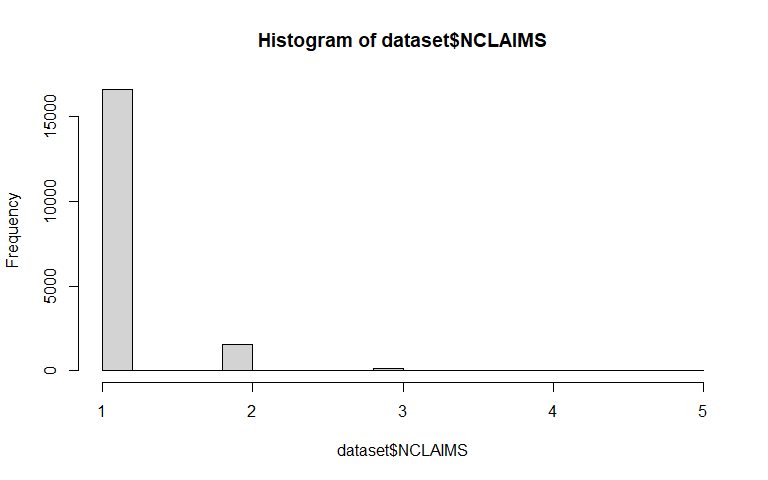

```r
dataset <- mtpl_be %>% filter(NCLAIMS>0)
set.seed(42)  # For reproducibility
in_training = createDataPartition(dataset$AVG, times = 1, p = 0.8, list = FALSE)
training_set = dataset[in_training, ]
testing_set = dataset[-in_training, ]
hist(dataset$NCLAIMS)
```

```r
sev0 <- recipe(AVG ~ COVERAGE + FUEL + SEX + USE + FLEET + AGEPH_fac +
                 AGEC_fac + POWER_fac + BM_fac, data = training_set)

s0_mod <- linear_reg() %>%
  set_engine("glm", family = Gamma(link = "log"))

s0_wflow <-
  workflow() %>%
  add_model(s0_mod, formula = AVG ~ . ) %>% # Formula of the model
  add_recipe(sev0)

s0_fit <- fit(s0_wflow, data = training_set)
summary(extract_fit_engine(s0_fit))
```

```
##
## Call:
## stats::glm(formula = AVG ~ ., family = ~Gamma(link = "log"),
##     data = data)
##
## Coefficients:
##                        Estimate Std. Error t value Pr(>|t|)
## (Intercept)           7.0059136  0.2272564  30.828   <2e-16 ***
## COVERAGEPO           -0.1283723  0.1317785  -0.974   0.3300
## COVERAGEFO            0.2626444  0.1812865   1.449   0.1474
## FUELgasoline          0.1677912  0.1196754   1.402   0.1609
## SEXfemale             0.0952951  0.1229255   0.775   0.4382
## USEwork              -0.0005477  0.2524809  -0.002   0.9983
## FLEETY               -0.3031253  0.3272373  -0.926   0.3543
## AGEPH_fac(43.7,56.5] -0.0551190  0.1423727  -0.387   0.6987
## AGEPH_fac(56.5,69.3] -0.3169405  0.1711375  -1.852   0.0641 .
## AGEPH_fac(17.9,30.8] -0.2008319  0.1601721  -1.254   0.2099
## AGEPH_fac(69.3,82.2] -0.0404612  0.2396931  -0.169   0.8660
## AGEPH_fac(82.2,95.1]  0.0389405  0.7361010   0.053   0.9578
## AGEC_fac(5,9]         0.1628502  0.1375450   1.184   0.2364
## AGEC_fac(9,48]        0.2436375  0.1542065   1.580   0.1141
## POWER_fac(40,48]     -0.0688098  0.1739690  -0.396   0.6925
## POWER_fac(48,55]      0.0838101  0.1669307   0.502   0.6156
## POWER_fac(55,66]      0.3620102  0.1802207   2.009   0.0446 *
## POWER_fac(66,243]     0.0407447  0.1745376   0.233   0.8154
## BM_fac(0,5]          -0.0019317  0.1356572  -0.014   0.9886
## BM_fac(5,11]          0.2784222  0.1553684   1.792   0.0732 .
## BM_fac(11,22]         0.3094075  0.2717810   1.138   0.2550
## ---
## Signif. codes:  0 '***' 0.001 '**' 0.01 '*' 0.05 '.' 0.1 ' ' 1
##
## (Dispersion parameter for Gamma family taken to be 41.61009)
##
##     Null deviance: 37162  on 14637  degrees of freedom
## Residual deviance: 35636  on 14617  degrees of freedom
## AIC: 239017
##
## Number of Fisher Scoring iterations: 16
```

```r
resS0 = fit_resamples(s0_wflow,
                    resamples = folds,
                    metrics = metric_set(rmse, mae))
collect_metrics(resS0) %>%
  mutate(
    mean = sprintf("%.6f", mean),
    std_err = sprintf("%.6f", std_err)
  )
```

```
## # A tibble: 2 × 6
##   .metric .estimator mean             n std_err     .config
##   <chr>   <chr>      <chr>        <int> <chr>       <chr>
## 1 mae     standard   1829.345764      5 149.500933  pre0_mod0_post0
## 2 rmse    standard   13358.073248     5 6370.667349 pre0_mod0_post0
```

```r
BIC(extract_fit_engine(s0_fit))
```

```
## [1] 239183.8
```

The early conclusion we can made based on the summary of our base model above is that no coefficient seems to be significant to predict the average claim amount, except maybe for horsepower. When we take a deeper look at what we are trying to predict, it seems fair that none of these information do have a link or influence on the claim amount, or at least have a direct relationship. So far we only find medium Power range being (barely) significant. Let’s now try to add some interactions which might help with our model.

```r
sev1 <- recipe(AVG ~ COVERAGE + FUEL + SEX + USE + FLEET + AGEPH_fac +
                 AGEC_fac + POWER_fac + BM_fac , data = training_set)

s1_mod <- linear_reg() %>%
  set_engine("glm", family = Gamma(link = "log"))

s1_wflow <-
  workflow() %>%
  add_model(s1_mod, formula = AVG ~ FUEL*POWER_fac + AGEPH_fac*BM_fac + COVERAGE*BM_fac+ . ) %>% # Formula of the model
  add_recipe(sev1)

s1_fit <- fit(s1_wflow, data = training_set)
summary(extract_fit_engine(s1_fit))
```

```
##
## Call:
## stats::glm(formula = AVG ~ FUEL * POWER_fac + AGEPH_fac * BM_fac +
##     COVERAGE * BM_fac + ., family = ~Gamma(link = "log"), data = data)
##
## Coefficients: (1 not defined because of singularities)
##                                    Estimate Std. Error t value Pr(>|t|)
## (Intercept)                         7.03522    0.30375  23.161   <2e-16 ***
## FUELgasoline                        0.03858    0.24379   0.158   0.8743
## POWER_fac(40,48]                   -0.09583    0.26503  -0.362   0.7177
## POWER_fac(48,55]                   -0.08460    0.26335  -0.321   0.7480
## POWER_fac(55,66]                    0.12495    0.30531   0.409   0.6824
## POWER_fac(66,243]                   0.01852    0.33197   0.056   0.9555
## AGEPH_fac(43.7,56.5]                0.01396    0.22489   0.062   0.9505
## AGEPH_fac(56.5,69.3]               -0.28049    0.25313  -1.108   0.2679
## AGEPH_fac(17.9,30.8]                0.02186    0.58643   0.037   0.9703
## AGEPH_fac(69.3,82.2]                0.14106    0.32228   0.438   0.6616
## AGEPH_fac(82.2,95.1]               -0.33083    1.17381  -0.282   0.7781
## BM_fac(0,5]                        -0.01141    0.24168  -0.047   0.9623
## BM_fac(5,11]                        0.59373    0.25772   2.304   0.0212 *
## BM_fac(11,22]                       0.40821    0.47050   0.868   0.3856
## COVERAGEPO                         -0.05307    0.20490  -0.259   0.7956
## COVERAGEFO                          0.38782    0.26641   1.456   0.1455
## SEXfemale                           0.07157    0.11062   0.647   0.5177
## USEwork                             0.04243    0.22777   0.186   0.8522
## FLEETY                             -0.29021    0.29438  -0.986   0.3242
## AGEC_fac(5,9]                       0.14723    0.12441   1.183   0.2367
## AGEC_fac(9,48]                      0.21731    0.14074   1.544   0.1226
## FUELgasoline:POWER_fac(40,48]      -0.04040    0.33053  -0.122   0.9027
## FUELgasoline:POWER_fac(48,55]       0.25358    0.31965   0.793   0.4276
## FUELgasoline:POWER_fac(55,66]       0.23131    0.35163   0.658   0.5107
## FUELgasoline:POWER_fac(66,243]      0.02543    0.36608   0.069   0.9446
## AGEPH_fac(43.7,56.5]:BM_fac(0,5]    0.17437    0.30187   0.578   0.5635
## AGEPH_fac(56.5,69.3]:BM_fac(0,5]    0.23420    0.34897   0.671   0.5022
## AGEPH_fac(17.9,30.8]:BM_fac(0,5]   -0.09485    0.64137  -0.148   0.8824
## AGEPH_fac(69.3,82.2]:BM_fac(0,5]   -0.09378    0.46792  -0.200   0.8411
## AGEPH_fac(82.2,95.1]:BM_fac(0,5]    0.70363    1.46840   0.479   0.6318
## AGEPH_fac(43.7,56.5]:BM_fac(5,11]  -0.53826    0.34657  -1.553   0.1204
## AGEPH_fac(56.5,69.3]:BM_fac(5,11]  -0.47806    0.43482  -1.099   0.2716
## AGEPH_fac(17.9,30.8]:BM_fac(5,11]  -0.39850    0.62276  -0.640   0.5223
```

[output cut: 8 more lines]

```
## BM_fac(5,11]:COVERAGEPO            -0.06346    0.30065  -0.211   0.8328
## BM_fac(11,22]:COVERAGEPO            0.49784    0.57208   0.870   0.3842
## BM_fac(0,5]:COVERAGEFO             -0.05368    0.34937  -0.154   0.8779
## BM_fac(5,11]:COVERAGEFO            -0.37060    0.38108  -0.972   0.3308
## BM_fac(11,22]:COVERAGEFO           -0.92899    0.77813  -1.194   0.2326
## ---
## Signif. codes:  0 '***' 0.001 '**' 0.01 '*' 0.05 '.' 0.1 ' ' 1
##
## (Dispersion parameter for Gamma family taken to be 33.57241)
##
##     Null deviance: 37162  on 14637  degrees of freedom
## Residual deviance: 35157  on 14593  degrees of freedom
## AIC: 238806
##
## Number of Fisher Scoring iterations: 25
```

```r
resS1 = fit_resamples(s1_wflow,
                    resamples = folds,
                    metrics = metric_set(rmse, mae))
collect_metrics(resS1) %>%
  mutate(
    mean = sprintf("%.6f", mean),
    std_err = sprintf("%.6f", std_err)
  )
```

```
## # A tibble: 2 × 6
##   .metric .estimator mean            n std_err .config
##   <chr>   <chr>      <chr>       <int> <chr>   <chr>
## 1 mae     standard   1616.861516     1 NA      pre0_mod0_post0
## 2 rmse    standard   5684.110132     1 NA      pre0_mod0_post0
```

```r
BIC(extract_fit_engine(s1_fit))
```

```
## [1] 239155.1
```

```r
anova(extract_fit_engine(s0_fit), extract_fit_engine(s1_fit), test= "Chisq")
```

```
## Analysis of Deviance Table
##
## Model 1: AVG ~ COVERAGE + FUEL + SEX + USE + FLEET + AGEPH_fac + AGEC_fac +
##     POWER_fac + BM_fac
## Model 2: AVG ~ FUEL * POWER_fac + AGEPH_fac * BM_fac + COVERAGE * BM_fac +
##     (COVERAGE + FUEL + SEX + USE + FLEET + AGEPH_fac + AGEC_fac +
##         POWER_fac + BM_fac)
##   Resid. Df Resid. Dev Df Deviance Pr(>Chi)
## 1     14617      35636
## 2     14593      35157 24   478.24   0.9409
```

The results from the anova test with respect to the extended model with interaction cannot reject the hypothesis of all additional coefficients to be 0. We thus prefer the simplified model.

```r
sev2 <- recipe(AVG ~ COVERAGE + FUEL + SEX + USE + FLEET + AGEPH_fac +
                 AGEC_fac + POWER_fac + BM_fac , data = training_set)

s2_mod <- linear_reg() %>%
  set_engine("glm", family = Gamma(link = "log"))

s2_wflow <-
  workflow() %>%
  add_model(s2_mod, formula = AVG ~  SEX * POWER_fac+ . ) %>% # Formula of the model
  add_recipe(sev2)

s2_fit <- fit(s2_wflow, data = training_set)
summary(extract_fit_engine(s2_fit))
```

```
##
## Call:
## stats::glm(formula = AVG ~ SEX * POWER_fac + ., family = ~Gamma(link = "log"),
##     data = data)
##
## Coefficients:
##                              Estimate Std. Error t value Pr(>|t|)
## (Intercept)                  7.138195   0.188159  37.937  < 2e-16 ***
## SEXfemale                   -0.136056   0.183265  -0.742   0.4579
## POWER_fac(40,48]            -0.124316   0.166327  -0.747   0.4548
## POWER_fac(48,55]             0.063771   0.158248   0.403   0.6870
## POWER_fac(55,66]            -0.056425   0.167382  -0.337   0.7360
## POWER_fac(66,243]           -0.087186   0.160953  -0.542   0.5880
## COVERAGEPO                  -0.175656   0.102273  -1.718   0.0859 .
## COVERAGEFO                   0.245316   0.140670   1.744   0.0812 .
## FUELgasoline                 0.121342   0.092938   1.306   0.1917
## USEwork                      0.018544   0.196026   0.095   0.9246
## FLEETY                      -0.270794   0.253948  -1.066   0.2863
## AGEPH_fac(43.7,56.5]         0.040049   0.110489   0.362   0.7170
## AGEPH_fac(56.5,69.3]        -0.245714   0.132805  -1.850   0.0643 .
## AGEPH_fac(17.9,30.8]        -0.061283   0.124342  -0.493   0.6221
## AGEPH_fac(69.3,82.2]         0.024996   0.186091   0.134   0.8932
## AGEPH_fac(82.2,95.1]         0.087706   0.571487   0.153   0.8780
## AGEC_fac(5,9]                0.158964   0.106786   1.489   0.1366
## AGEC_fac(9,48]               0.150280   0.119800   1.254   0.2097
## BM_fac(0,5]                  0.004416   0.105268   0.042   0.9665
## BM_fac(5,11]                 0.200146   0.120580   1.660   0.0970 .
## BM_fac(11,22]                0.168440   0.210906   0.799   0.4245
## SEXfemale:POWER_fac(40,48]  -0.006748   0.276718  -0.024   0.9805
## SEXfemale:POWER_fac(48,55]  -0.175470   0.270716  -0.648   0.5169
## SEXfemale:POWER_fac(55,66]   1.316727   0.301701   4.364 1.28e-05 ***
## SEXfemale:POWER_fac(66,243]  0.352627   0.296617   1.189   0.2345
## ---
## Signif. codes:  0 '***' 0.001 '**' 0.01 '*' 0.05 '.' 0.1 ' ' 1
##
## (Dispersion parameter for Gamma family taken to be 25.05346)
##
##     Null deviance: 37162  on 14637  degrees of freedom
## Residual deviance: 34956  on 14613  degrees of freedom
## AIC: 238656
##
## Number of Fisher Scoring iterations: 18
```

```r
resS2 = fit_resamples(s2_wflow,
                    resamples = folds,
                    metrics = metric_set(rmse, mae))
collect_metrics(resS2) %>%
  mutate(
    mean = sprintf("%.6f", mean),
    std_err = sprintf("%.6f", std_err)
  )
```

```
## # A tibble: 2 × 6
##   .metric .estimator mean             n std_err     .config
##   <chr>   <chr>      <chr>        <int> <chr>       <chr>
## 1 mae     standard   1839.467727      5 147.857359  pre0_mod0_post0
## 2 rmse    standard   13375.081099     5 6366.340023 pre0_mod0_post0
```

```r
BIC(extract_fit_engine(s2_fit))
```

```
## [1] 238853.2
```

Clearly, doing so step-by-step while no coefficient is ever significant, we will first evaluate if a model with only the intercept might be a good solution with respect to the anova test. If not, we will do the step by step iteration and aim for the best performance indicators and best highest anova p-value.

```r
sev_I <- recipe(AVG ~ COVERAGE + FUEL + FLEET + USE + SEX +  AGEPH_fac +
                 AGEC_fac + POWER_fac + BM_fac , data = training_set)


sI_mod <- linear_reg() %>%
  set_engine("glm", family = Gamma(link = "log"))

sI_wflow <-
  workflow() %>%
  add_model(sI_mod, formula = AVG ~ 1  ) %>% # Formula of the model
  add_recipe(sev_I)

sI_fit <- fit(sI_wflow, data = training_set)
summary(extract_fit_engine(sI_fit))
```

```
##
## Call:
## stats::glm(formula = AVG ~ 1, family = ~Gamma(link = "log"),
##     data = data)
##
## Coefficients:
##             Estimate Std. Error t value Pr(>|t|)
## (Intercept)  7.38637    0.09265   79.73   <2e-16 ***
## ---
## Signif. codes:  0 '***' 0.001 '**' 0.01 '*' 0.05 '.' 0.1 ' ' 1
##
## (Dispersion parameter for Gamma family taken to be 125.6423)
##
##     Null deviance: 37162  on 14637  degrees of freedom
## Residual deviance: 37162  on 14637  degrees of freedom
## AIC: 239784
##
## Number of Fisher Scoring iterations: 7
```

```r
resSI = fit_resamples(sI_wflow,
                    resamples = folds,
                    metrics = metric_set(rmse, mae))
collect_metrics(resSI) %>%
  mutate(
    mean = sprintf("%.6f", mean),
    std_err = sprintf("%.6f", std_err)
  )
```

```
## # A tibble: 2 × 6
##   .metric .estimator mean             n std_err     .config
##   <chr>   <chr>      <chr>        <int> <chr>       <chr>
## 1 mae     standard   1806.717919      5 147.646328  pre0_mod0_post0
## 2 rmse    standard   13348.117195     5 6375.011109 pre0_mod0_post0
```

```r
BIC(extract_fit_engine(sI_fit))
```

```
## [1] 239799.2
```

```r
anova(extract_fit_engine(s0_fit), extract_fit_engine(sI_fit), test= "Chisq")
```

```
## Analysis of Deviance Table
##
## Model 1: AVG ~ COVERAGE + FUEL + SEX + USE + FLEET + AGEPH_fac + AGEC_fac +
##     POWER_fac + BM_fac
## Model 2: AVG ~ 1
##   Resid. Df Resid. Dev  Df Deviance Pr(>Chi)
## 1     14617      35636
## 2     14637      37162 -20  -1526.3  0.01278 *
## ---
## Signif. codes:  0 '***' 0.001 '**' 0.01 '*' 0.05 '.' 0.1 ' ' 1
```

Clearly the in-sample metrics perform poorly but regarding cross validation, the out-of-sample performance is much better. Additionally, the anova tests, reject the hypothesis that the coefficients withdrawn are equal to 0. Therefore, at least one of them must be important. Now we will iteratively remove arguments to find the model with optimal metrics. First we will remove coefficient that appear the least relevant based on their significance. We start by removing the *USE* and *FLEET* arguments.

```r
sev3 <- recipe(AVG ~ COVERAGE + FUEL + AGEPH_fac + SEX +
                 AGEC_fac + POWER_fac + BM_fac , data = training_set)

s3_mod <- linear_reg() %>%
  set_engine("glm", family = Gamma(link = "log"))

s3_wflow <-
  workflow() %>%
  add_model(s3_mod, formula = AVG ~  . ) %>% # Formula of the model
  add_recipe(sev3)

s3_fit <- fit(s3_wflow, data = training_set)
summary(extract_fit_engine(s3_fit))
```

```
##
## Call:
## stats::glm(formula = AVG ~ ., family = ~Gamma(link = "log"),
##     data = data)
##
## Coefficients:
##                       Estimate Std. Error t value Pr(>|t|)
## (Intercept)           7.005200   0.227615  30.777   <2e-16 ***
## COVERAGEPO           -0.131453   0.131939  -0.996   0.3191
## COVERAGEFO            0.253307   0.181073   1.399   0.1619
## FUELgasoline          0.170644   0.119665   1.426   0.1539
## AGEPH_fac(43.7,56.5] -0.057163   0.142672  -0.401   0.6887
## AGEPH_fac(56.5,69.3] -0.325584   0.171400  -1.900   0.0575 .
## AGEPH_fac(17.9,30.8] -0.201379   0.160430  -1.255   0.2094
## AGEPH_fac(69.3,82.2] -0.049210   0.240078  -0.205   0.8376
## AGEPH_fac(82.2,95.1]  0.007856   0.737586   0.011   0.9915
## SEXfemale             0.093480   0.123215   0.759   0.4481
## AGEC_fac(5,9]         0.161565   0.137868   1.172   0.2413
## AGEC_fac(9,48]        0.244169   0.154561   1.580   0.1142
## POWER_fac(40,48]     -0.068054   0.174404  -0.390   0.6964
## POWER_fac(48,55]      0.080272   0.167324   0.480   0.6314
## POWER_fac(55,66]      0.359855   0.180623   1.992   0.0464 *
## POWER_fac(66,243]     0.032922   0.174340   0.189   0.8502
## BM_fac(0,5]          -0.003974   0.135978  -0.029   0.9767
## BM_fac(5,11]          0.279483   0.155744   1.794   0.0728 .
## BM_fac(11,22]         0.310496   0.271277   1.145   0.2524
## ---
## Signif. codes:  0 '***' 0.001 '**' 0.01 '*' 0.05 '.' 0.1 ' ' 1
##
## (Dispersion parameter for Gamma family taken to be 41.82092)
##
##     Null deviance: 37162  on 14637  degrees of freedom
## Residual deviance: 35668  on 14619  degrees of freedom
## AIC: 239030
##
## Number of Fisher Scoring iterations: 16
```

```r
resS3 = fit_resamples(s3_wflow,
                    resamples = folds,
                    metrics = metric_set(rmse, mae))
collect_metrics(resS3) %>%
  mutate(
    mean = sprintf("%.6f", mean),
    std_err = sprintf("%.6f", std_err)
  )
```

```
## # A tibble: 2 × 6
##   .metric .estimator mean             n std_err     .config
##   <chr>   <chr>      <chr>        <int> <chr>       <chr>
## 1 mae     standard   1828.710699      5 149.589692  pre0_mod0_post0
## 2 rmse    standard   13357.968973     5 6370.692421 pre0_mod0_post0
```

```r
BIC(extract_fit_engine(s3_fit))
```

```
## [1] 239182.1
```

```r
anova(extract_fit_engine(s0_fit), extract_fit_engine(s3_fit), test= "Chisq")
```

```
## Analysis of Deviance Table
##
## Model 1: AVG ~ COVERAGE + FUEL + SEX + USE + FLEET + AGEPH_fac + AGEC_fac +
##     POWER_fac + BM_fac
## Model 2: AVG ~ COVERAGE + FUEL + AGEPH_fac + SEX + AGEC_fac + POWER_fac +
##     BM_fac
##   Resid. Df Resid. Dev Df Deviance Pr(>Chi)
## 1     14617      35636
## 2     14619      35668 -2  -32.517   0.6766
```

Unfortunately, we did not make any step forward in terms of coefficients that are significant but the anova test shows that we should choose the simplified model. Next, we remove *SEX*.

```r
sev4 <- recipe(AVG ~  FUEL  + AGEPH_fac + COVERAGE +
                 AGEC_fac + POWER_fac + BM_fac , data = training_set)

s4_mod <- linear_reg() %>%
  set_engine("glm", family = Gamma(link = "log"))

s4_wflow <-
  workflow() %>%
  add_model(s4_mod, formula = AVG ~ . ) %>% # Formula of the model
  add_recipe(sev4)

s4_fit <- fit(s4_wflow, data = training_set)
summary(extract_fit_engine(s4_fit))
```

```
##
## Call:
## stats::glm(formula = AVG ~ ., family = ~Gamma(link = "log"),
##     data = data)
##
## Coefficients:
##                       Estimate Std. Error t value Pr(>|t|)
## (Intercept)           7.043084   0.228138  30.872   <2e-16 ***
## FUELgasoline          0.182972   0.120741   1.515   0.1297
## AGEPH_fac(43.7,56.5] -0.074621   0.145219  -0.514   0.6074
## AGEPH_fac(56.5,69.3] -0.345182   0.173956  -1.984   0.0472 *
## AGEPH_fac(17.9,30.8] -0.221121   0.163309  -1.354   0.1758
## AGEPH_fac(69.3,82.2] -0.076036   0.243788  -0.312   0.7551
## AGEPH_fac(82.2,95.1] -0.028633   0.750183  -0.038   0.9696
## COVERAGEPO           -0.130539   0.134374  -0.971   0.3313
## COVERAGEFO            0.258403   0.184348   1.402   0.1610
## AGEC_fac(5,9]         0.157315   0.140407   1.120   0.2626
## AGEC_fac(9,48]        0.243075   0.157377   1.545   0.1225
## POWER_fac(40,48]     -0.074724   0.177345  -0.421   0.6735
## POWER_fac(48,55]      0.066096   0.169683   0.390   0.6969
## POWER_fac(55,66]      0.358613   0.182373   1.966   0.0493 *
## POWER_fac(66,243]     0.015645   0.174943   0.089   0.9287
## BM_fac(0,5]          -0.004583   0.138345  -0.033   0.9736
## BM_fac(5,11]          0.289571   0.158324   1.829   0.0674 .
## BM_fac(11,22]         0.323456   0.276266   1.171   0.2417
## ---
## Signif. codes:  0 '***' 0.001 '**' 0.01 '*' 0.05 '.' 0.1 ' ' 1
##
## (Dispersion parameter for Gamma family taken to be 43.38336)
##
##     Null deviance: 37162  on 14637  degrees of freedom
## Residual deviance: 35691  on 14620  degrees of freedom
## AIC: 239041
##
## Number of Fisher Scoring iterations: 13
```

```r
resS4 = fit_resamples(s4_wflow,
                    resamples = folds,
                    metrics = metric_set(rmse, mae))
collect_metrics(resS4) %>%
  mutate(
    mean = sprintf("%.6f", mean),
    std_err = sprintf("%.6f", std_err)
  )
```

```
## # A tibble: 2 × 6
##   .metric .estimator mean             n std_err     .config
##   <chr>   <chr>      <chr>        <int> <chr>       <chr>
## 1 mae     standard   1830.281580      5 149.282387  pre0_mod0_post0
## 2 rmse    standard   13357.845795     5 6370.840714 pre0_mod0_post0
```

```r
BIC(extract_fit_engine(s4_fit))
```

```
## [1] 239184.9
```

```r
anova(extract_fit_engine(s0_fit), extract_fit_engine(s4_fit), test= "Chisq")
```

```
## Analysis of Deviance Table
##
## Model 1: AVG ~ COVERAGE + FUEL + SEX + USE + FLEET + AGEPH_fac + AGEC_fac +
##     POWER_fac + BM_fac
## Model 2: AVG ~ FUEL + AGEPH_fac + COVERAGE + AGEC_fac + POWER_fac + BM_fac
##   Resid. Df Resid. Dev Df Deviance Pr(>Chi)
## 1     14617      35636
## 2     14620      35691 -3   -55.49   0.7212
```

```r
anova(extract_fit_engine(s3_fit), extract_fit_engine(s4_fit), test= "Chisq")
```

```
## Analysis of Deviance Table
##
## Model 1: AVG ~ COVERAGE + FUEL + AGEPH_fac + SEX + AGEC_fac + POWER_fac +
##     BM_fac
## Model 2: AVG ~ FUEL + AGEPH_fac + COVERAGE + AGEC_fac + POWER_fac + BM_fac
##   Resid. Df Resid. Dev Df Deviance Pr(>Chi)
## 1     14619      35668
## 2     14620      35691 -1  -22.973   0.4586
```

It appears that removing the SEX factors make the model perform worse than *sev3*. Instead, we will add SEX back and remove Coverage.

```r
sev5 <- recipe(AVG ~ FUEL + SEX +  AGEPH_fac +
                 AGEC_fac + POWER_fac + BM_fac , data = training_set)


s5_mod <- linear_reg() %>%
  set_engine("glm", family = Gamma(link = "log"))

s5_wflow <-
  workflow() %>%
  add_model(s5_mod, formula = AVG ~ . ) %>% # Formula of the model
  add_recipe(sev5)

s5_fit <- fit(s5_wflow, data = training_set)
summary(extract_fit_engine(s5_fit))
```

```
##
## Call:
## stats::glm(formula = AVG ~ ., family = ~Gamma(link = "log"),
##     data = data)
##
## Coefficients:
##                       Estimate Std. Error t value Pr(>|t|)
## (Intercept)           7.071112   0.210409  33.607   <2e-16 ***
## FUELgasoline          0.155572   0.118998   1.307   0.1911
## SEXfemale             0.101178   0.122629   0.825   0.4093
## AGEPH_fac(43.7,56.5] -0.061065   0.142048  -0.430   0.6673
## AGEPH_fac(56.5,69.3] -0.317372   0.170627  -1.860   0.0629 .
## AGEPH_fac(17.9,30.8] -0.205440   0.159643  -1.287   0.1982
## AGEPH_fac(69.3,82.2] -0.065966   0.238993  -0.276   0.7825
## AGEPH_fac(82.2,95.1] -0.031442   0.734241  -0.043   0.9658
## AGEC_fac(5,9]         0.083069   0.128762   0.645   0.5188
## AGEC_fac(9,48]        0.189654   0.139380   1.361   0.1736
## POWER_fac(40,48]     -0.078523   0.173593  -0.452   0.6510
## POWER_fac(48,55]      0.050882   0.166532   0.306   0.7600
## POWER_fac(55,66]      0.348092   0.179694   1.937   0.0527 .
## POWER_fac(66,243]     0.050040   0.173190   0.289   0.7726
## BM_fac(0,5]           0.003144   0.135375   0.023   0.9815
## BM_fac(5,11]          0.279230   0.154706   1.805   0.0711 .
## BM_fac(11,22]         0.259895   0.269928   0.963   0.3356
## ---
## Signif. codes:  0 '***' 0.001 '**' 0.01 '*' 0.05 '.' 0.1 ' ' 1
##
## (Dispersion parameter for Gamma family taken to be 41.45841)
##
##     Null deviance: 37162  on 14637  degrees of freedom
## Residual deviance: 35847  on 14621  degrees of freedom
## AIC: 239122
##
## Number of Fisher Scoring iterations: 15
```

```r
resS5 = fit_resamples(s5_wflow,
                    resamples = folds,
                    metrics = metric_set(rmse, mae))
collect_metrics(resS5) %>%
  mutate(
    mean = sprintf("%.6f", mean),
    std_err = sprintf("%.6f", std_err)
  )
```

```
## # A tibble: 2 × 6
##   .metric .estimator mean             n std_err     .config
##   <chr>   <chr>      <chr>        <int> <chr>       <chr>
## 1 mae     standard   1827.917231      5 148.884558  pre0_mod0_post0
## 2 rmse    standard   13358.627196     5 6370.636035 pre0_mod0_post0
```

```r
BIC(extract_fit_engine(s5_fit))
```

```
## [1] 239258.8
```

```r
anova(extract_fit_engine(s0_fit), extract_fit_engine(s5_fit), test= "Chisq")
```

```
## Analysis of Deviance Table
##
## Model 1: AVG ~ COVERAGE + FUEL + SEX + USE + FLEET + AGEPH_fac + AGEC_fac +
##     POWER_fac + BM_fac
## Model 2: AVG ~ FUEL + SEX + AGEPH_fac + AGEC_fac + POWER_fac + BM_fac
##   Resid. Df Resid. Dev Df Deviance Pr(>Chi)
## 1     14617      35636
## 2     14621      35847 -4     -211   0.2801
```

Clearly results are worse than when we add only removed *SEX*. Since adding and removing one coefficient at a time is heavy in computations and fluctuates a lot without us being able to determine a solid pattern, we will make an assumption and remove *COVERAGE*, *SEX*, *FUEL* *USE* and *FLEET* from the base model.

```r
sev6 <- recipe(AVG ~   AGEPH_fac + AGEC_fac + POWER_fac + BM_fac , data = training_set)


s6_mod <- linear_reg() %>%
  set_engine("glm", family = Gamma(link = "log"))

s6_wflow <-
  workflow() %>%
  add_model(s6_mod, formula = AVG ~ .) %>% # Formula of the model
  add_recipe(sev6)

s6_fit <- fit(s6_wflow, data = training_set)
summary(extract_fit_engine(s6_fit))
```

```
##
## Call:
## stats::glm(formula = AVG ~ ., family = ~Gamma(link = "log"),
##     data = data)
##
## Coefficients:
##                       Estimate Std. Error t value Pr(>|t|)
## (Intercept)           7.226341   0.203495  35.511   <2e-16 ***
## AGEPH_fac(43.7,56.5] -0.087225   0.149674  -0.583   0.5601
## AGEPH_fac(56.5,69.3] -0.327921   0.178996  -1.832   0.0670 .
## AGEPH_fac(17.9,30.8] -0.231883   0.168191  -1.379   0.1680
## AGEPH_fac(69.3,82.2] -0.057146   0.249277  -0.229   0.8187
## AGEPH_fac(82.2,95.1] -0.021393   0.772328  -0.028   0.9779
## AGEC_fac(5,9]         0.093653   0.135353   0.692   0.4890
## AGEC_fac(9,48]        0.204000   0.146121   1.396   0.1627
## POWER_fac(40,48]     -0.132564   0.180145  -0.736   0.4618
## POWER_fac(48,55]      0.011564   0.173075   0.067   0.9467
## POWER_fac(55,66]      0.347974   0.187856   1.852   0.0640 .
## POWER_fac(66,243]     0.048383   0.179536   0.269   0.7876
## BM_fac(0,5]          -0.006572   0.142602  -0.046   0.9632
## BM_fac(5,11]          0.297552   0.162815   1.828   0.0676 .
## BM_fac(11,22]         0.270857   0.284600   0.952   0.3413
## ---
## Signif. codes:  0 '***' 0.001 '**' 0.01 '*' 0.05 '.' 0.1 ' ' 1
##
## (Dispersion parameter for Gamma family taken to be 46.10354)
##
##     Null deviance: 37162  on 14637  degrees of freedom
## Residual deviance: 35956  on 14623  degrees of freedom
## AIC: 239177
##
## Number of Fisher Scoring iterations: 13
```

```r
resS6 = fit_resamples(s6_wflow,
                    resamples = folds,
                    metrics = metric_set(rmse, mae))
collect_metrics(resS6) %>%
  mutate(
    mean = sprintf("%.6f", mean),
    std_err = sprintf("%.6f", std_err)
  )
```

```
## # A tibble: 2 × 6
##   .metric .estimator mean             n std_err     .config
##   <chr>   <chr>      <chr>        <int> <chr>       <chr>
## 1 mae     standard   1829.212792      5 148.273730  pre0_mod0_post0
## 2 rmse    standard   13358.414291     5 6370.841257 pre0_mod0_post0
```